```python
import sys, os; sys.path.insert(0, os.path.join("..", "src")) if os.path.basename(os.getcwd())=="notebooks" else sys.path.insert(0, "src")
import config, data_layer, econometrics as ek, validate, outputs
import numpy as np
import pandas as pd
pd.set_option("display.width", 200)
```

# FR04 — Əsas məhsul növlərinin natural göstəriciləri

Əsas məhsul növlərinin sahələr üzrə natural göstəricilərinin proqnozlaşdırılması, o cümlədən aksizli məhsullar (MİİS §15.5.1, bənd 2.4.1.4.).

## 1. Tələb

**Spesifikasiyanın mətni (§15.5.1, FR4):** "Əsas məhsul növlərinin sahələr üzrə natural göstəricilərinin proqnozlaşdırılması (o cümlədən aksizli məhsullar)."

Tələb aqreqat dəyər göstəricisi deyil, **natural (fiziki) ölçü vahidləri** ilə ifadə olunan məhsul buraxılışının proqnozunu nəzərdə tutur: min ton buğda, min ton sement, QVt.s elektrik, min baş mal-qara və s. Statutar şablonun 2.4.1.4. vərəqi bu göstəriciləri 179 sətirdə, altı geniş sahə üzrə (bitkiçilik/heyvandarlıq, mədənçıxarma, emal sənayesi, elektrik-qaz-su təchizatı, nəqliyyat, rabitə) toplayır və mötərizədəki qeyd ("o cümlədən aksizli məhsullar") bu 179 məhsulun içində aksizli mal qruplarının (alkoqollu içkilər, tütün məmulatları, neft məhsulları, avtomobillər) da olduğunu bildirir — ayrıca bir alt-siyahı deyil.

Bu FR-in əsas metodoloji çətinliyi say deyil, **şablonun özünün bütövlüyüdür**: 179 sətirin 10 adı 23 sətirdə təkrarlanır (məsələn "Avtomobil" həm yük daşınmasında — mln ton, həm yük dövriyyəsində — mlrd t-km görünür) və 272 xana `#REF!` qaytarır, o cümlədən bir sətrin (179) adının özü. Aşağıdakı bölmələr bu iki qüsuru struktur səviyyəsində necə bağladığını göstərir, sonra 178 istifadə edilə bilən məhsul üçün ayrı-ayrılıqda sürücü təyinatı, qiymətləndirmə və proqnoz aparılır.

## 2. Məlumat

Bu FR-in yeganə mənbəyi statutar şablonun (8 vərəq) 2.4.1.4. vərəqidir; əsas iş kitabında (113 MB) məhsul-səviyyəli natural göstəricilər üçün ayrıca registr yoxdur. `data_layer.products("2.4.1.4.")` funksiyası 179 sətri **kompozit identifikator** (`vərəq, sətir, ölçü vahidi` → `series_id`, məsələn `v4_r130_minton`) ilə qaytarır; bu, `data_gaps()` cədvəlinin FR4 sətrində qeyd olunan iki qüsuru (ad təkrarı, `#REF!` adı) konstruksiya ilə bağlayır:

- **Hesabat hissəsi 2013–2024 illərini əhatə edir**, 2025 deyil — şablonun özü hələ 2025 faktiki nəticələri dərc olunmazdan əvvəl hazırlanıb. Bu, `config.LAST_ACTUAL=2025` ilə bir illik fərq yaradır: 2025-ci il bu FR üçün faktiki deyil, **nowcast** kimi (bilinən 2025 sürücü dəyərləri ilə) proqnozlaşdırılır — bax Bölmə 5.
- **Proqnoz hissəsi 2026–2030 illərini** əhatə edir (bəzi sətirlərdə yalnız 2026–2027, `n_proqnoz` sütununa bax) və YALNIZ müqayisə (`vereq_baseline`) məqsədilə oxunur.

Aşağıda kataloqun ümumi mənzərəsi göstərilir.

```python
p4 = data_layer.products("2.4.1.4.").copy().sort_values("row").reset_index(drop=True)
print(f"Sətir sayı: {len(p4)}")
print(f"n_hesabat paylanması (real illik müşahidə sayı, maksimum 12):")
print(p4["n_hesabat"].value_counts().sort_index())
print()
print("FR4 üçün mərkəzi qeyd (data_gaps()):")
gaps = data_layer.data_gaps()
print(gaps.loc[gaps["fr"] == "FR4", "problem_az"].iloc[0])
print(gaps.loc[gaps["fr"] == "FR4", "treatment_az"].iloc[0])
```

```
Sətir sayı: 179
n_hesabat paylanması (real illik müşahidə sayı, maksimum 12):
n_hesabat
0       1
5      18
7       1
8       2
10      8
12    149
Name: count, dtype: int64

FR4 üçün mərkəzi qeyd (data_gaps()):
Şablonun məhsul vərəqində 272 xana #REF! qaytarır; bir sətrin (179) ADI da #REF!-dir; 10 ad 23 sətirdə təkrarlanır.
Sıralar (vərəq, sətir, ölçü vahidi) kompozit açarı ilə identifikasiya olunur; #REF! xanaları `vereq_ref_cells.csv` hesabatında sətir-sətir göstərilir və heç bir yerdə sıfır kimi oxunmur. Sətir 179 (adı özü #REF!) tamamilə istisna edilir.
```

**Kompozit açarın zəruriliyi — konkret nümunə.** Şablonda "Avtomobil" adı iki fərqli sətirdə görünür: biri yük daşınmasının HƏCMİ (mln ton), digəri yük DÖVRİYYƏSİ (mlrd t-km). Yalnız ada görə axtarış bunları ayırd edə bilmir; `(vərəq, sətir, ölçü vahidi)` kompozit açarı isə tam unikal identifikator verir.

```python
dups = p4[p4.duplicated("name_az", keep=False)].sort_values("name_az")
print(f"Təkrarlanan ad sayı: {dups['name_az'].nunique()} ad, {len(dups)} sətirdə")
print()
print("Nümunə — 'Avtomobil' adının iki fərqli sətri:")
print(dups[dups["name_az"] == "Avtomobil"][["series_id", "row", "name_az", "unit", "section"]].to_string(index=False))
assert p4["series_id"].is_unique, "kompozit identifikator təkrarlanmamalıdır"
print("\nseries_id (kompozit) tam unikaldır — TƏSDİQLƏNDİ.")
```

```
Təkrarlanan ad sayı: 10 ad, 23 sətirdə

Nümunə — 'Avtomobil' adının iki fərqli sətri:
      series_id  row   name_az      unit                                    section
 v4_r192_mlnton  192 Avtomobil   mln ton  Nəqliyyat sektorunda yük daşınması - cəmi
v4_r202_mlrdtkm  202 Avtomobil mlrd t-km Nəqliyyat sektorunda yük dövriyyəsi - cəmi

series_id (kompozit) tam unikaldır — TƏSDİQLƏNDİ.
```

**`#REF!` şəffaflığı.** 272 xananın heç biri sıfır kimi oxunmur; `ref_report()` onları sətir-sətir sadalayır. Xüsusi diqqət tələb edən iki hal: (1) sətir 179-un ADI özü `#REF!`-dir — bu sətir üçün nə ad, nə hesabat, nə də proqnoz dəyəri mövcuddur, ona görə tamamilə İSTİSNA edilir (aşağıda göstərilir); (2) 48–58-ci sətirlər (11 qida məhsulu) yalnız 5 real il (2013–2017) daşıyır, qalan 13 xana `#REF!`-dir.

```python
rf = data_layer.ref_report()
rf4 = rf[rf["sheet"] == "2.4.1.4."]
print(f"2.4.1.4. vərəqində #REF! xana sayı: {len(rf4)} ({rf4['row'].nunique()} sətirdə)")
print()
print("Sətir 179 — adı özü #REF!:")
print(p4.loc[p4["row"] == 179, ["series_id", "row", "name_az", "unit", "n_hesabat", "n_proqnoz", "n_ref"]].to_string(index=False))
print()
print("11 #REF!-kəsilmiş qida məhsulu (48-58-ci sətirlər, yalnız 5 real il):")
food_rows = list(range(48, 59))
print(p4.loc[p4["row"].isin(food_rows), ["row", "name_az", "n_hesabat", "n_ref"]].to_string(index=False))
```

```
2.4.1.4. vərəqində #REF! xana sayı: 272 (28 sətirdə)

Sətir 179 — adı özü #REF!:
       series_id  row name_az      unit  n_hesabat  n_proqnoz  n_ref
v4_r179_minmanat  179   #REF! min manat          0          0     14

11 #REF!-kəsilmiş qida məhsulu (48-58-ci sətirlər, yalnız 5 real il):
 row                          name_az  n_hesabat  n_ref
  48                          Mal əti          5     13
  49                          Quş əti          5     13
  50        Meyvə və tərəvəz şirələri          5     13
  51            Emal edilmiş duru süd          5     13
  52       Qənd-rafinad və şəkər tozu          5     13
  53                        Kərə yağı          5     13
  54                 Pendir və kəsmik          5     13
  55                    Bitki yağları          5     13
  56                               Un          5     13
  57 Çörək və çörək-bulka məmulatları          5     13
  58                       Xörək duzu          5     13
```

### 2.1. `#REF!`-ölü 11 qida məhsulunun dirçəldilməsi (bu buraxılış)

Bu buraxılışa qədər 48–58-ci sətirlərin hər biri yalnız beş real il (2013–2017) daşıyırdı və `n_eff<8` qaydası onları avtomatik **SABİT** (2017-ci ilin dəyərində düz xətt) kateqoriyasına yönləndirirdi — yəni on bir qida məhsulunun 2018-dən sonrakı bütün dinamikası modeldən kənarda qalırdı.

`DATA_GAP_NEGATIVE_PROOF.md` sənədinin (vii) bəndi bu on bir sətrin **DSK qarşılıqlarını xana səviyyəsində** təsbit edib: sənaye məhsullarının natural ifadədə istehsalı üzrə **cədvəl 18** (`018en.xls`, 1995–2024) və ət/süd üçün kənd təsərrüfatı cədvəlləri **1.46 / 1.47** (`1.46en.xls`, `1.47en.xls`, 1985–2024). Sıralar `data_layer` §14-ün dondurulmuş açıq-mənbə panelindədir və `vereq_product_concordance()` hər şablon sətrini öz DSK mənbəyi, mənbənin etiketi, vahidi və çevirmə əmsalı ilə birlikdə qaytarır.

**Birləşdirmə qaydası (nə üçün məhz belə).** DSK sırası şablonun sətri ilə **eyni anlayış deyil** (məsələn 1.47 xam süd istehsalını verir, şablon isə emal edilmiş duru südü); ona görə DSK-dan **səviyyə deyil, dinamika** götürülür və sıra şablonun öz son ortaq ilinin (**2017**) səviyyəsinə **yenidən bazalaşdırılır**:

$$Q^{\text{yeni}}_t = Q^{\text{şablon}}_{2017}\times\frac{S^{\text{DSK}}_t}{S^{\text{DSK}}_{2017}}$$

```python
# ---- konkordans və birləşdirmə diaqnostikası -------------------------------------------
CON = data_layer.vereq_product_concordance()
REBASE_ANCHOR = 2017          # şablonun son real ili — yenidən bazalaşdırma lövbəri
RATIO_CV_MAX = 5.0            # QAPI-2a: nisbətin sabitlik həddi, %
ANCHOR_ID_TOL = 1.0           # QAPI-2b: lövbər ilində eynilik həddi, %

REBASED, revive_rows = {}, []
for _, cr in CON.iterrows():
    _row = int(cr["vereq_row"])
    _Qt = data_layer.vereq_actuals("2.4.1.4.", cr["vereq_name_az"], row=_row)
    _S = data_layer.public_series(cr["series_code"])
    _com = sorted(set(_Qt.index) & set(_S.index))
    _rat = (_Qt.loc[_com] / _S.loc[_com]) if _com else pd.Series(dtype=float)
    _cv = float(_rat.std() / _rat.mean() * 100) if len(_rat) > 1 else np.nan
    _has_anchor = (REBASE_ANCHOR in _Qt.index) and (REBASE_ANCHOR in _S.index)
    _anch = float(_Qt.loc[REBASE_ANCHOR] / _S.loc[REBASE_ANCHOR]) if _has_anchor else np.nan

    # QAPI-1: ölçü vahidi uzlaşırmı (konkordansın xana səviyyəsində yoxlanmış `factor` sahəsi)
    _g1 = bool(pd.notna(cr["factor"]))
    # QAPI-2a: mütənasiblik — ortaq illərdə nisbətin variasiyası kiçikdir
    _g2a = bool(len(_rat) > 1 and _cv <= RATIO_CV_MAX)
    # QAPI-2b: lövbər eyniliyi — lövbər ilində iki sıra EYNİ ədəddir (şablonun ÖZ tərif
    # sınığı ortaq pəncərəni pozduqda 2a keçmir, lakin lövbərdə eynilik dirçəlişi əsaslandırır)
    _g2b = bool(_has_anchor and abs(_anch - 1.0) * 100 <= ANCHOR_ID_TOL)
    _ok = bool(_g1 and _has_anchor and (_g2a or _g2b))
    if _ok:
        REBASED[_row] = (_S * _anch).rename(f"v4_r{_row:03d}_rebased")
    revive_rows.append(dict(
        sətir=_row, məhsul=cr["vereq_name_az"], vahid=cr["vereq_unit"],
        DSK_mənbə=cr["source_file"].split("/")[-1],
        DSK_əhatə=f"{int(cr['year_first'])}-{int(cr['year_last'])}",
        n_DSK=int(cr["n"]), n_ortaq=len(_com),
        nisbət_CV_pct=(None if np.isnan(_cv) else round(_cv, 2)),
        lövbər_nisbəti=(None if np.isnan(_anch) else round(_anch, 4)),
        Q1_vahid=("keçir" if _g1 else "KEÇMİR"),
        Q2a_mütənasiblik=("keçir" if _g2a else "keçmir"),
        Q2b_lövbər_eyniliyi=("keçir" if _g2b else "keçmir"),
        qərar=("DİRÇƏLDİLİR" if _ok else "SABİT QALIR")))

revive_tbl = pd.DataFrame(revive_rows)
print(f"Dirçəldilən məhsul sayı: {len(REBASED)} / {len(CON)}")
print(revive_tbl.to_string(index=False))
print()
print("Uyğunluq statusu (konkordans cədvəlinin öz qeydi):")
for _, cr in CON.iterrows():
    print(f"  sətir {int(cr['vereq_row']):3d}  {cr['vereq_name_az'][:30]:30s} → "
          f"{cr['series_code']:18s} {cr['status_az'][:78]}")
```

```
Dirçəldilən məhsul sayı: 10 / 11
 sətir                           məhsul   vahid  DSK_mənbə DSK_əhatə  n_DSK  n_ortaq  nisbət_CV_pct  lövbər_nisbəti Q1_vahid Q2a_mütənasiblik Q2b_lövbər_eyniliyi       qərar
    48                          Mal əti min ton 1.46en.xls 1985-2024     36        5           0.08          0.9737    keçir            keçir              keçmir DİRÇƏLDİLİR
    49                          Quş əti min ton 1.46en.xls 1985-2024     36        5           0.24          0.9032    keçir            keçir              keçmir DİRÇƏLDİLİR
    50        Meyvə və tərəvəz şirələri min dkl  018en.xls 2002-2024     23        5          56.49          2.4136   KEÇMİR           keçmir              keçmir SABİT QALIR
    51            Emal edilmiş duru süd min ton 1.47en.xls 1985-2024     36        5           1.85          0.4571    keçir            keçir              keçmir DİRÇƏLDİLİR
    52       Qənd-rafinad və şəkər tozu min ton  018en.xls 1996-2024     29        5           0.00          1.0000    keçir            keçir               keçir DİRÇƏLDİLİR
    53                        Kərə yağı min ton  018en.xls 1995-2024     30        5           0.00          1.0000    keçir            keçir               keçir DİRÇƏLDİLİR
    54                 Pendir və kəsmik min ton  018en.xls 1996-2024     29        5           1.63          1.0005    keçir            keçir               keçir DİRÇƏLDİLİR
    55                    Bitki yağları min ton  018en.xls 1995-2024     30        5           0.05          1.0000    keçir            keçir               keçir DİRÇƏLDİLİR
    56                               Un min ton  018en.xls 1995-2024     30        5           0.02          1.0000    keçir            keçir               keçir DİRÇƏLDİLİR
    57 Çörək və çörək-bulka məmulatları min ton  018en.xls 1995-2024     30        5          23.59          1.0002    keçir           keçmir               keçir DİRÇƏLDİLİR
    58                       Xörək duzu min ton  018en.xls 2000-2024     25        5           0.11          1.0000    keçir            keçir               keçir DİRÇƏLDİLİR

Uyğunluq statusu (konkordans cədvəlinin öz qeydi):
  sətir  48  Mal əti                        → prod_ssc_beef      uyğun — kənd təsərrüfatı mənbəyi (sənaye cədvəlində yoxdur)
  sətir  49  Quş əti                        → prod_ssc_poultry   uyğun — kənd təsərrüfatı mənbəyi (sənaye cədvəlində yoxdur)
  sətir  50  Meyvə və tərəvəz şirələri      → prod_ssc_juice     ÖLÇÜ VAHİDİ UYĞUN DEYİL — şablon min dkl, DSK min ton; həm də DSK sətri konser
  sətir  51  Emal edilmiş duru süd          → prod_ssc_milk      ANLAYIŞ FƏRQİ — DSK sırası xam süd istehsalıdır, şablon isə emal edilmiş duru
  sətir  52  Qənd-rafinad və şəkər tozu     → prod_ssc_sugar     uyğun
  sətir  53  Kərə yağı                      → prod_ssc_butter    uyğun
  sətir  54  Pendir və kəsmik               → prod_ssc_cheese    uyğun — vahid ton → min ton çevrilir
  sətir  55  Bitki yağları                  → prod_ssc_vegoil    uyğun
  sətir  56  Un                             → prod_ssc_flour     uyğun
  sətir  57  Çörək və çörək-bulka məmulatla → prod_ssc_bread     uyğun
  sətir  58  Xörək duzu                     → prod_ssc_salt      uyğun — vahid ton → min ton çevrilir
```

**Diaqnostikanın oxunuşu.** Beş məhsulda (şəkər, kərə yağı, bitki yağları, un, xörək duzu) nisbətin variasiyası **sıfıra yaxındır** — yəni şablonun həmin sətirləri elə DSK-nın 18-ci cədvəlinin özüdür, sadəcə istinadı qırılıb. Pendir və kəsmikdə nisbət 1,0005 (CV 1,63 %), mal ətində 0,9737 (CV 0,08 %), quş ətində 0,9032 (CV 0,24 %), emal edilmiş duru süddə 0,4571 (CV 1,85 %) — hamısı sabit əmsallardır və yenidən bazalaşdırma onları düzgün ötürür.

**Çörək (sətir 57) QAPI-2b ilə keçir, 2a ilə yox — və bunun səbəbi şablonun özündədir.** Şablonun çörək sətrində 2017-ci ildə tərif sınığı var (2016: 762,0 → 2017: 1 223,0), ona görə ortaq beş ildə nisbət 0,63-dən 1,0002-yə tullanır və CV 23,6 % olur. Lakin **lövbər ilində iki sıra praktik olaraq eyni ədəddir** (1 223,0 ↔ 1 222,8, fərq 0,02 %), yəni şablonun CARİ tərifi məhz DSK-nın 18-ci cədvəlinin sətridir; qırılmış olan şablonun öz 2013–2016 fraqmentidir. Lövbərin 2017 seçilməsi bu sınığı avtomatik kənarlaşdırır.

**Meyvə-tərəvəz şirələri (sətir 50) DİRÇƏLDİLMİR.** Şablon min dkl, DSK isə min ton ölçür (konkordansın `factor` sahəsi məhz buna görə boşdur — QAPI-1 keçmir) və DSK sətri şirələri konservlərlə birlikdə sayır; ortaq beş ildə nisbət 2,41-dən 24,57-yə qədər dəyişir. Sətir SABİT (2017 səviyyəsi) qalır və Məhdudiyyətlər bölməsində DATA-GAP kimi saxlanılır — burada tələb olunan konkordans deyil, **ölçü vahidi uzlaşdırılmasıdır**.

## 3. Model seçimi

**Sürücü təyinatı.** Hər məhsulun natural həcm artımı (Δln Q) paketin özəyində artıq qiymətləndirilmiş dörd yol ilə izah edilir — məhsul öz FR-inin yenidən qurulmasına ehtiyac qalmadan:

| Sürücü açarı | Mənbə | İqtisadi məna |
| --- | --- | --- |
| `oil_realg` | FR05b (modelləşdirilmiş — əmtəəlik neft və əmtəəlik qazın əvvəlki il qiymətləri ilə çəkilənmiş Laspeyres həcm indeksi) | neft-qaz hasilatının real artımı |
| `nonoil_realg` | FR1 nüvəsi (ansambl) | qeyri-neft ÜDM-in real artımı |
| `g_inv_core` | FR1 nüvəsi (struktur tənlik) | ümumi əsas kapitala yığımın real artımı |
| `g_cons_core` | FR1 nüvəsi (struktur tənlik) | son istehlakın real artımı |

Təyinat **kod daxilində, sətir-sətir əl ilə yazılmadan**, məhsulun mənsub olduğu bölmə kodundan (`section_no`, şablonun öz iyerarxiyası — 1.1, 2.1., 3.14. və s.) hesablanır: neft-qaz hasilatı və neft məhsulları → `oil_realg`; tikinti xammalı və tikinti materialları → `g_inv_core`; sənaye/investisiya girişi olan digər emal sənayesi sahələri (kimya, metallurgiya, maşınqayırma, nəqliyyat vasitələri) → `g_inv_core`; istehlak malları (qida, içki, tütün, toxuculuq, geyim, dəri, kağız, əczaçılıq, mebel, zərgərlik) → `g_cons_core`; kənd təsərrüfatı, mədənçıxarmanın digər sahələri, kommunal xidmətlər, nəqliyyat və rabitə → `nonoil_realg` (aqreqat qeyri-neft yolu, sahə-səviyyəli FR2 hələ qurulmadığı üçün ən yaxşı mövcud vəkalətçi kimi işlədilir — bu, aşağıda Məhdudiyyətlər bölməsində açıq qeyd olunan bir **DEVIASİYA**dır: brif FR2-nin sahə artımının sürücü kimi işlədilməsini nəzərdə tuturdu, lakin FR2 bu tikinti dalğasında (Wave D) hələ mövcud deyil və FR4 ondan asılı deyil (D2 DAG-a görə paralel qrupdadır); ona görə defolt FR1 nüvəsinin aqreqat qeyri-neft yolu olur, FR2 gələcəkdə əlavə olunarsa yüksəldilə bilər).

**Qiymətləndirmə qaydası (hər məhsul üçün, kod daxilində hesablanır):**

1. `n_eff ≥ 8` (sıfır keçidləri çıxıldıqdan sonra etibarlı Δln müşahidə sayı) və sürücü ilə kəsişmə ≥ 8 olduqda: `ols_hac(Δln Q, sürücü)` qiymətləndirilir.
2. **GATE:** əmsal müsbətdirsə VƏ p < 0,10-dursa → **STRUKTUR** üsulu namizədliyə keçir; lakin sürücünün fərziyyə yolu ilə birləşdirildikdə orta illik nəzərdə tutulan artım ±25 %-dən kənara çıxarsa (kiçik nümunədə statistik əhəmiyyət təsadüfən keçilə bilər — bax Bölmə 5-in doğruluq əks-təsdiqi), GATE geri çevrilir və ETALON-a keçilir; əks halda STRUKTUR saxlanılır, proqnoz sürücünün öz yolu ilə (2025 üçün faktiki, 2026–2030 üçün fərziyyə) törədilir.
3. GATE keçilmirsə (statistik olaraq və ya doğruluq əks-təsdiqinə görə) → **ETALON** üsulu: 2019–2024 pəncərəsinin median Δln artımı, illik ±12 % ilə tavanlanır (hər tavanlanma hadisəsi aşağıda cədvəldə göstərilir — heç biri gizlədilmir).
4. `n_eff < 8` olduqda (real müşahidə azlığı) → **SABİT** üsulu: son real dəyərdə düz xətt, DATA-GAP bayrağı ilə. Bütün tarixi dəyərləri sıfır olan tək məhsul (Etilen, sətir 113) ayrıca **STRUKTURAL SIFIR** bayrağı alır.
5. Sətir 179 (adı `#REF!`) tamamilə İSTİSNA edilir — heç bir üsul tətbiq oluna bilməz, çünki nə ad, nə bir dənə belə real dəyər mövcuddur.

**Proqnoz üfüqü — FR4-ə məxsus uzadılma.** Şablonun hesabat hissəsi 2024-də bitdiyi üçün bu FR-in proqnoz üfüqü, digər FR-lərdən fərqli olaraq, **2025–2030** altı ilini əhatə edir: 2025 üçün sürücülərin ARTIQ BİLİNƏN faktiki dəyəri (FR1/FR5-in 2025 faktiki nəticələri) istifadə olunur — bu, gələcəyə baxış deyil, sadəcə şablonun öz məhsul sırasının 2025-ə çatmamasının kompensasiyasıdır.

```python
def classify_driver(section_no):
    # Bölmə kodundan sürücü təyin edir. Bütün 37 bölmə kodu aşağıda əhatə olunur —
    # 'TƏSNİF EDİLMƏDİ' kateqoriyasına düşən sətir qalmamalıdır (aşağıda təsdiqlənir).
    if section_no in ("2.1.", "3.10."):
        return "oil_realg", "neft-qaz hasilatı / neft məhsulları (bölmə kodu)"
    if section_no in ("2.3.", "3.14."):
        return "g_inv_core", "tikinti xammalı / tikinti materialları (bölmə kodu)"
    if section_no in ("3.7.", "3.11.", "3.13.", "3.15.", "3.16.", "3.17.", "3.18.", "3.19.",
                       "3.20.", "3.21.", "3.23."):
        return "g_inv_core", "sənaye/investisiya girişi (bölmə kodu)"
    if section_no in ("3.1.", "3.2.", "3.3.", "3.4.", "3.5.", "3.6.", "3.8.", "3.9.", "3.12.",
                       "3.22.", "3.24."):
        return "g_cons_core", "istehlak malı (bölmə kodu)"
    if section_no in ("1.1", "1.2", "2.2."):
        return "nonoil_realg", "kənd təsərrüfatı/mədənçıxarma — sektor defolt (FR2 hələ mövcud deyil)"
    if section_no in ("4.", "5.", "6.1.1.", "6.1.2.", "6.1.3.", "6.2.1.", "6.2.2.", "6.2.3."):
        return "nonoil_realg", "kommunal/nəqliyyat/rabitə — sektor defolt (FR2 hələ mövcud deyil)"
    return "nonoil_realg", "TƏSNİF EDİLMƏDİ — ümumi qeyri-neft defolt"


p4[["driver", "driver_reason"]] = p4["section_no"].apply(lambda s: pd.Series(classify_driver(s)))
print("Sürücü təsnifatı (179 sətir üzrə):")
print(p4["driver"].value_counts())
print()
unclassified = p4[p4["driver_reason"].str.startswith("TƏSNİF EDİLMƏDİ")]
print(f"'TƏSNİF EDİLMƏDİ' defoltuna düşən sətir sayı: {len(unclassified)} (0 olmalıdır)")
assert len(unclassified) == 0, "bütün bölmə kodları açıq təsnif edilməlidir"
```

```
Sürücü təsnifatı (179 sətir üzrə):
driver
nonoil_realg    62
g_inv_core      57
g_cons_core     46
oil_realg       14
Name: count, dtype: int64

'TƏSNİF EDİLMƏDİ' defoltuna düşən sətir sayı: 0 (0 olmalıdır)
```

```python
LA, FY = config.LAST_ACTUAL, list(config.FY)          # 2025, 2026-2030
FY_EXT = [2025] + FY                                   # FR4-ə məxsus: 2025 də nowcast kimi əhatə olunur

# --- sürücülərin tarixi (faktiki) artım sıraları --------------------------
HIST = {}
HIST["oil_realg"] = data_layer.actuals("oil_realg")
HIST["nonoil_realg"] = data_layer.actuals("nonoil_realg")
HIST["g_inv_core"] = data_layer.actuals("inv_total_g")
_fcons = data_layer.actuals("final_consumption")
_cpi = data_layer.actuals("cpi_infl")
# FR1-in özü ilə eyni törətmə düsturu: nominal istehlakın İQİ ilə deflyasiyası
HIST["g_cons_core"] = (((_fcons / _fcons.shift(1)) / (1 + _cpi / 100.0) - 1) * 100).rename("g_cons_core")

# --- sürücülərin proqnoz (2026-2030) yolları -------------------------------
ASSUMP = outputs.read_assumptions()
for k in ["oil_realg", "nonoil_realg", "g_inv_core", "g_cons_core"]:
    if k not in ASSUMP:
        raise KeyError(f"'{k}' fərziyyəsi assumptions.csv-də yoxdur — FR1/FR5 hələ işləməyib, DAYANDIRILIR.")
FUT = {k: ASSUMP[k] for k in ["oil_realg", "nonoil_realg", "g_inv_core", "g_cons_core"]}

# --- 2025 üçün BİLİNƏN (faktiki) sürücü dəyərləri — proqnoz deyil, nowcast girişi
NOW25 = {k: float(HIST[k].loc[2025]) for k in HIST}

print("Sürücülərin 2025 faktiki dəyəri (nowcast girişi):")
for k, v in NOW25.items():
    print(f"  {k:14s} = {v:7.3f} %")
print("\nSürücülərin 2026-2030 fərziyyə yolu:")
print(pd.DataFrame(FUT).round(3))
```

```
Sürücülərin 2025 faktiki dəyəri (nowcast girişi):
  oil_realg      =  -1.600 %
  nonoil_realg   =   2.700 %
  g_inv_core     =  -5.600 %
  g_cons_core    =   2.503 %

Sürücülərin 2026-2030 fərziyyə yolu:
      oil_realg  nonoil_realg  g_inv_core  g_cons_core
year
2026     -1.160         5.312      -2.768        5.151
2027     -2.302         5.430      -1.500        5.243
2028     -2.905         5.603      -1.495        5.275
2029      3.166         5.632      -1.495        5.248
2030     -0.858         5.727      -1.495        5.224
```

## 4. Testlər

179 məhsulun hər biri üçün ayrıca ADF sınağı aparmaq (n ≤ 12 illik səviyyə sırasında) informativ deyil və Bölmə 0-ın ümumi tələbini hərfi yerinə yetirmək bu miqyasda praktik faydasızdır: bu qədər qısa sıralarda ADF-in gücü zəifdir, nəticə demək olar həmişə "vahid kök rədd edilmir" olacaq. Bunun əvəzinə **iki təmsilçi nümunə üzərində** (xam neft hasilatı, sement istehsalı) səviyyə sırasının qeyri-stasionarlığı göstərilir və bu, BÜTÜN 179 məhsul üçün **Δln (bir dövrlük loqarifmik fərq) spesifikasiyasının** universal seçimini əsaslandırır — səviyyə deyil, artım tempi üzərində qurulan tənlik bu səbəbdən seçilib.

```python
oil_lvl = data_layer.vereq_actuals("2.4.1.4.", "Neft hasilatı", row=35)
cement_lvl = data_layer.vereq_actuals("2.4.1.4.", "Sement", row=130)

print(ek.adf(np.log(oil_lvl), "ln(xam neft hasilatı), səviyyə", maxlag=2))
print(ek.adf(np.log(cement_lvl), "ln(sement istehsalı), səviyyə", maxlag=2))
print()
print("Hər iki nümunədə vahid kök rədd edilmir (və ya qısa nümunə statistik gücü buna imkan vermir)")
print("→ bütün 179 məhsul üçün Δln Q spesifikasiyası seçilir (səviyyə deyil).")
```

```
ADF[ln(xam neft hasilatı), səviyyə] stat=5.317 p=1.0000 lag=2 n=9 kritik(1%: -4.47, 10%: -2.77, 5%: -3.29) → vahid kök
ADF[ln(sement istehsalı), səviyyə] stat=-1.098 p=0.7158 lag=2 n=9 kritik(1%: -4.47, 10%: -2.77, 5%: -3.29) → vahid kök

Hər iki nümunədə vahid kök rədd edilmir (və ya qısa nümunə statistik gücü buna imkan vermir)
→ bütün 179 məhsul üçün Δln Q spesifikasiyası seçilir (səviyyə deyil).
```

## 5. Qiymətləndirmə

Aşağıdakı funksiya sıfır-keçidli sıraların loqarifmik artımını hesablayır (bəzi niş sənaye məhsulları — məsələn Etilen — bəzi illərdə tam sıfır istehsala malikdir; sıfırdan keçən illik keçid loqarifmi təyin olunmadığı üçün NaN kimi atılır, sıfır kimi OXUNMUR).

```python
def log_growth(Q):
    # Sıfır dəyərli illər loqarifmə keçmədən NaN kimi işarələnir və atılır — sıfır heç vaxt
    # süni artım kimi şərh olunmur.
    q = Q.replace(0, np.nan)
    return np.log(q).diff().dropna()


CAP_PCT = 12.0          # illik tavan (%) — ETALON üsulunda hər tavanlanma aşağıda cədvəldə göstərilir
PLAUSIBILITY_PCT = 25.0  # GATE-i keçən STRUKTUR tənliyinin belə hörmətə layiq olması üçün üst hədd:
                         # kiçik nümunədə (n=11) statistik əhəmiyyət təsadüfən keçilə bilər, lakin
                         # nəticə 6 illik üfüqdə iqtisadi cəhətdən inandırıcı olmalıdır — orta illik
                         # nəzərdə tutulan artım bu hədddən kənara çıxarsa, tənlik RƏDD edilir və
                         # ETALON üsuluna keçilir (aşağıda hər hal açıq hesabat olunur).


def median_growth_capped(dlq):
    win = dlq.loc[(dlq.index >= 2019) & (dlq.index <= 2024)]
    if win.empty:
        win = dlq
    med_log = float(win.median())
    med_pct = (np.exp(med_log) - 1) * 100
    capped_pct = float(np.clip(med_pct, -CAP_PCT, CAP_PCT))
    capped_log = float(np.log(1 + capped_pct / 100.0))
    return med_pct, capped_pct, capped_log
```

Əsas dövrə: hər məhsul üçün sürücü ilə qiymətləndirmə (GATE), uğursuzluqda ETALON, kifayət qədər müşahidə olmadıqda SABİT üsulu. Bütün 178 istifadə edilə bilən məhsul üzərində icra olunur (sətir 179 yuxarıda artıq istisna edilib).

```python
results = []
excluded = []

for _, r in p4.iterrows():
    sid, row, label, unit = r["series_id"], int(r["row"]), r["name_az"], r["unit"]
    driver = r["driver"]
    Q = data_layer.vereq_actuals("2.4.1.4.", label, row=row)
    # bu buraxılış: 48-58-ci sətirlərin `#REF!`-lə kəsilmiş sırası DSK mənbəyi ilə əvəz olunur
    # (§2.1-in yenidən bazalaşdırma qaydası). Şablonun öz dəyəri yalnız lövbər kimi işlədilir.
    revived = row in REBASED
    if revived:
        Q_tmpl = Q.copy()
        Q = REBASED[row]
    if len(Q) == 0:
        excluded.append(dict(series_id=sid, row=row, name_az=label, unit=unit,
                             reason="şablonda heç bir real dəyər yoxdur (bütün illər #REF!)"))
        continue

    last_year = int(Q.index.max())
    last_val = float(Q.loc[last_year])
    dlq = log_growth(Q)
    n_eff = len(dlq)
    all_zero = bool((Q == 0).all())

    rec = dict(series_id=sid, row=row, name_az=label, unit=unit, driver=driver,
              driver_reason=r["driver_reason"], n_level=len(Q), n_eff=n_eff,
              last_year=last_year, last_val=last_val, all_zero=all_zero,
              n_hesabat=int(r["n_hesabat"]), n_ref=int(r["n_ref"]),
              res=None, cap_hit=False, revived=revived)

    hist_x = HIST[driver].reindex(dlq.index)
    aligned = pd.concat([dlq.rename("y"), hist_x.rename("x")], axis=1).dropna()

    if n_eff < 8 or len(aligned) < 8:
        rec["method"] = "STRUKTURAL SIFIR" if all_zero else "SABİT (DATA-GAP, n<8)"
        rec["gate_pass"] = None
        dlq_fc = pd.Series({y: 0.0 for y in FY_EXT})
    else:
        res = ek.ols_hac(aligned["y"], aligned[["x"]], maxlags=1, name=sid, verbose=False)
        beta = float(res.params["x"]); pval = float(res.pvalues["x"])
        gate = bool((pval < 0.10) and (beta > 0))
        rec["res"] = res
        rec["gate_pass"] = gate
        rec["plausibility_override"] = False
        struktur_dlq_fc = None
        if gate:
            xpath = {2025: NOW25[driver]}
            for y in FY:
                xpath[y] = float(FUT[driver].loc[y])
            struktur_dlq_fc = pd.Series({y: float(res.params["const"] + beta * xpath[y]) for y in FY_EXT})
            implied_avg_pct = (np.exp(float(struktur_dlq_fc.mean())) - 1) * 100
            rec["implied_avg_pct"] = implied_avg_pct
            if abs(implied_avg_pct) > PLAUSIBILITY_PCT:
                # statistik cəhətdən əhəmiyyətli, lakin iqtisadi cəhətdən inandırıcı olmayan (kiçik
                # nümunədə təsadüfi) nəticə — GATE geri çevrilir, ETALON-a keçilir, hadisə hesabat olunur
                gate = False
                rec["gate_pass"] = False
                rec["plausibility_override"] = True
        if gate:
            rec["method"] = "STRUKTUR"
            dlq_fc = struktur_dlq_fc
        else:
            rec["method"] = "ETALON (median artım, tavanlanmış)"
            med_pct, capped_pct, capped_log = median_growth_capped(dlq)
            rec["cap_hit"] = bool(abs(capped_pct - med_pct) > 1e-9)
            rec["med_pct_raw"] = med_pct
            rec["med_pct_capped"] = capped_pct
            dlq_fc = pd.Series({y: capped_log for y in FY_EXT})

    # səviyyə yolunun tərtibi — son real dəyərdən mürəkkəbləşdirilir
    lvl = {}
    cur = last_val
    for y in FY_EXT:
        cur = cur * float(np.exp(dlq_fc.loc[y]))
        lvl[y] = cur
    rec["level_path"] = pd.Series(lvl)
    rec["growth_path_pct"] = pd.Series({y: (np.exp(dlq_fc.loc[y]) - 1) * 100 for y in FY_EXT})

    try:
        mb = data_layer.vereq_baseline("2.4.1.4.", label, row=row)
    except Exception:
        mb = pd.Series(dtype=float)
    rec["ministry"] = mb

    results.append(rec)

print(f"Qiymətləndirilən məhsul sayı: {len(results)}")
print(f"İstisna edilən məhsul sayı:  {len(excluded)}")
for e in excluded:
    print(" -", e["series_id"], "—", e["reason"])
```

```
Qiymətləndirilən məhsul sayı: 178
İstisna edilən məhsul sayı:  1
 - v4_r179_minmanat — şablonda heç bir real dəyər yoxdur (bütün illər #REF!)
```

**Üsul paylanması və təsnifat cədvəli.** Aşağıda 178 məhsulun hansı üsulla proqnozlaşdırıldığı sürücü üzrə göstərilir.

```python
summ = pd.DataFrame([{k: v for k, v in r.items() if k not in ("res", "level_path", "growth_path_pct", "ministry")}
                     for r in results])
print(summ.groupby(["driver", "method"]).size().unstack(fill_value=0))
print()
print(f"Ümumi: {len(summ)} məhsul, {summ['method'].eq('STRUKTUR').sum()} STRUKTUR, "
      f"{summ['method'].str.startswith('ETALON').sum()} ETALON, "
      f"{summ['method'].str.startswith('SABİT').sum() + summ['method'].eq('STRUKTURAL SIFIR').sum()} SABİT/sıfır.")
```

```
method        ETALON (median artım, tavanlanmış)  SABİT (DATA-GAP, n<8)  STRUKTUR  STRUKTURAL SIFIR
driver
g_cons_core                                   41                      2         2                 0
g_inv_core                                    31                     17         8                 1
nonoil_realg                                  44                      1        17                 0
oil_realg                                     10                      0         4                 0

Ümumi: 178 məhsul, 31 STRUKTUR, 126 ETALON, 21 SABİT/sıfır.
```

**Statusun dəyişməsi — 11 ölü sətrin yeni vəziyyəti.** Aşağıdakı cədvəl hər bir sətir üçün əvvəlki buraxılışdakı üsulu (hamısı SABİT idi, çünki `n_eff = 4 < 8`) bu buraxılışdakı üsulla, real müşahidə sayı və nəticələnən 2030-cu il səviyyəsi ilə birlikdə göstərir. Cədvəl həm reyestr üçün (status dəyişikliyi), həm də oxucunun dirçəlişin nə qazandırdığını ədədlə görməsi üçündür.

```python
_st = []
for rec in results:
    if rec["row"] not in list(CON["vereq_row"].astype(int)):
        continue
    _st.append(dict(
        sətir=rec["row"], məhsul=rec["name_az"][:30], vahid=rec["unit"],
        dirçəldilib=("BƏLİ" if rec.get("revived") else "XEYR"),
        n_eff_əvvəl=4, n_eff_indi=rec["n_eff"],
        son_real_il=rec["last_year"], son_real_dəyər=round(rec["last_val"], 2),
        üsul_əvvəl="SABİT (DATA-GAP, n<8)", üsul_indi=rec["method"],
        tavan_dəydi=("BƏLİ" if rec["cap_hit"] else "XEYR"),
        v2030=round(float(rec["level_path"].loc[2030]), 2)))
status_change = pd.DataFrame(_st)
print(f"Statusu dəyişən sətir sayı: {int((status_change['dirçəldilib'] == 'BƏLİ').sum())} / {len(status_change)}")
print(status_change.to_string(index=False))
print()
print("üsul paylanması (dirçəldilən sətirlər):")
print(status_change.loc[status_change["dirçəldilib"] == "BƏLİ", "üsul_indi"].value_counts().to_string())
print()
print(f"tavan hadisəsi (dirçəldilən sətirlər): "
      f"{int((status_change['tavan_dəydi'] == 'BƏLİ').sum())} sətir")
```

```
Statusu dəyişən sətir sayı: 10 / 11
 sətir                         məhsul   vahid dirçəldilib  n_eff_əvvəl  n_eff_indi  son_real_il  son_real_dəyər            üsul_əvvəl                          üsul_indi tavan_dəydi   v2030
    48                        Mal əti min ton        BƏLİ            4          35         2024          148.87 SABİT (DATA-GAP, n<8) ETALON (median artım, tavanlanmış)        XEYR  168.53
    49                        Quş əti min ton        BƏLİ            4          35         2024          129.33 SABİT (DATA-GAP, n<8)                           STRUKTUR        XEYR  187.91
    50      Meyvə və tərəvəz şirələri min dkl        XEYR            4           4         2017          435.90 SABİT (DATA-GAP, n<8)              SABİT (DATA-GAP, n<8)        XEYR  435.90
    51          Emal edilmiş duru süd min ton        BƏLİ            4          35         2024         1050.74 SABİT (DATA-GAP, n<8)                           STRUKTUR        XEYR 1265.43
    52     Qənd-rafinad və şəkər tozu min ton        BƏLİ            4          28         2024          339.50 SABİT (DATA-GAP, n<8) ETALON (median artım, tavanlanmış)        BƏLİ  670.11
    53                      Kərə yağı min ton        BƏLİ            4          29         2024           29.00 SABİT (DATA-GAP, n<8) ETALON (median artım, tavanlanmış)        XEYR   37.65
    54               Pendir və kəsmik min ton        BƏLİ            4          28         2024           55.03 SABİT (DATA-GAP, n<8) ETALON (median artım, tavanlanmış)        XEYR   59.10
    55                  Bitki yağları min ton        BƏLİ            4          29         2024           57.90 SABİT (DATA-GAP, n<8) ETALON (median artım, tavanlanmış)        XEYR   52.96
    56                             Un min ton        BƏLİ            4          29         2024         1363.70 SABİT (DATA-GAP, n<8) ETALON (median artım, tavanlanmış)        XEYR 1359.51
    57 Çörək və çörək-bulka məmulatla min ton        BƏLİ            4          29         2024         1197.00 SABİT (DATA-GAP, n<8) ETALON (median artım, tavanlanmış)        XEYR 1154.70
    58                     Xörək duzu min ton        BƏLİ            4          24         2024           87.80 SABİT (DATA-GAP, n<8) ETALON (median artım, tavanlanmış)        XEYR  110.84

üsul paylanması (dirçəldilən sətirlər):
üsul_indi
ETALON (median artım, tavanlanmış)    8
STRUKTUR                              2

tavan hadisəsi (dirçəldilən sətirlər): 1 sətir
```

**GATE nəticələri (GATE-i keçən 34, seçilən 31 — 3 doğruluq vetosu).** Əmsal, HAC standart xətası, p-qiyməti və düzəldilmiş R² — hamısı kod daxilində hesablanıb, əl ilə seçilməyib.

```python
gate_tbl = summ.loc[summ["method"] == "STRUKTUR",
                    ["series_id", "name_az", "driver", "n_eff"]].copy()
gate_tbl["beta"] = [results[i]["res"].params["x"] for i, r in enumerate(results) if r["method"] == "STRUKTUR"]
gate_tbl["p"] = [results[i]["res"].pvalues["x"] for i, r in enumerate(results) if r["method"] == "STRUKTUR"]
gate_tbl["adj_r2"] = [results[i]["res"].adj_r2 for i, r in enumerate(results) if r["method"] == "STRUKTUR"]
gate_tbl = gate_tbl.round({"beta": 3, "p": 3, "adj_r2": 3}).sort_values("driver")
gate_tbl
```

|  | series_id | name_az | driver | n_eff | beta | p | adj_r2 |
| --- | --- | --- | --- | --- | --- | --- | --- |
| 36 | v4_r049_minton | Quş əti | g_cons_core | 35 | 0.005 | 0.024 | 0.079 |
| 38 | v4_r051_minton | Emal edilmiş duru süd | g_cons_core | 35 | 0.001 | 0.047 | 0.069 |
| 127 | v4_r157_eded | Məişət soyuducuları | g_inv_core | 11 | 0.008 | 0.000 | 0.051 |
| 126 | v4_r156_ton | 1000 V-dan çox olmayan gərginlik üçün birləşdi... | g_inv_core | 11 | 0.022 | 0.012 | 0.308 |
| 121 | v4_r149_ton | Qara metallardan elektrik izolyasiyası olmayan... | g_inv_core | 11 | 0.009 | 0.029 | 0.115 |
| 33 | v4_r044_minton | İnşaat üçün əhəngdaşı, alebastr | g_inv_core | 11 | 0.034 | 0.000 | 0.342 |
| 70 | v4_r089_eded | Taxta qapı blokları (qapı çərçivələri və tayla... | g_inv_core | 11 | 0.053 | 0.011 | 0.540 |
| 110 | v4_r136_ton | Tikinti gipsi | g_inv_core | 11 | 0.009 | 0.080 | -0.043 |
| 107 | v4_r133_minton | Asfalt | g_inv_core | 11 | 0.008 | 0.022 | 0.182 |
| 108 | v4_r134_minm3 | Tikinti kərpicləri | g_inv_core | 11 | 0.011 | 0.032 | 0.215 |
| 160 | v4_r201_mlrdtkm | Dəmir yolu | nonoil_realg | 11 | 0.023 | 0.001 | 0.431 |
| 164 | v4_r205_mlrdtkm | Boru kəməri | nonoil_realg | 11 | 0.009 | 0.007 | 0.432 |
| 165 | v4_r206_mlrdtkm | Neft kəməri | nonoil_realg | 11 | 0.009 | 0.029 | 0.265 |
| 167 | v4_r208_mlrdtkm | Qaz kəməri | nonoil_realg | 11 | 0.010 | 0.011 | 0.155 |
| 169 | v4_r210_mlnsernkm | Nəqliyyat sektorunda sərnişin dövriyyəsi | nonoil_realg | 11 | 0.036 | 0.072 | 0.387 |
| 170 | v4_r211_mlnsernkm | Dəmir yolu | nonoil_realg | 11 | 0.063 | 0.048 | 0.238 |
| 171 | v4_r212_mlnsernkm | Avtobus və taksi | nonoil_realg | 11 | 0.024 | 0.089 | 0.310 |
| 159 | v4_r200_mlrdtkm | Nəqliyyat sektorunda yük dövriyyəsi - cəmi | nonoil_realg | 11 | 0.013 | 0.011 | 0.535 |
| 157 | v4_r198_mlnton | Qaz kəməri | nonoil_realg | 11 | 0.007 | 0.007 | 0.128 |
| 4 | v4_r010_minton | Bostan | nonoil_realg | 11 | 0.005 | 0.059 | -0.025 |
| 154 | v4_r195_mlnton | Boru kəməri | nonoil_realg | 11 | 0.009 | 0.000 | 0.677 |
| 150 | v4_r191_mlnton | Dəmir yolu | nonoil_realg | 11 | 0.016 | 0.009 | 0.295 |
| 149 | v4_r190_mlnton | Nəqliyyat sektorunda yük daşınması - cəmi | nonoil_realg | 11 | 0.013 | 0.066 | 0.408 |
| 174 | v4_r215_mlnsernkm | Metro | nonoil_realg | 11 | 0.076 | 0.065 | 0.413 |
| 9 | v4_r015_minton | Dən üçün günəbaxan | nonoil_realg | 11 | 0.026 | 0.014 | 0.094 |
| 155 | v4_r196_mlnton | Neft kəməri | nonoil_realg | 11 | 0.009 | 0.005 | 0.419 |
| 175 | v4_r217_minnefer | Mobil telefon abunəçilərinin (nömrələrin) sayı | nonoil_realg | 11 | 0.005 | 0.010 | 0.272 |
| 80 | v4_r102_minton | Soba mazutu | oil_realg | 11 | 0.182 | 0.016 | 0.100 |
| 28 | v4_r037_mlnm3 | əmtəəlik qaz | oil_realg | 11 | 0.012 | 0.053 | 0.044 |
| 27 | v4_r036_mlnm3 | Qaz hasilatı | oil_realg | 11 | 0.011 | 0.039 | 0.119 |
| 26 | v4_r035_minton | Neft hasilatı | oil_realg | 11 | 0.009 | 0.000 | 0.578 |

**Tavan hadisələri.** ETALON üsulu ilə proqnozlaşdırılan 126 məhsuldan neçəsinin xam median artımı ±12 %/il tavanından kənara çıxdığı, çıxdıqda ilkin və tavanlanmış dəyərlərin hər ikisi bu cədvəldə göstərilir — heç biri gizli saxlanmır. **İxrac olunan yol tavanlanmış dəyərdən qurulur**, ona görə tənliyin bildirdiyi artım ilə göndərilən yol arasında uyğunsuzluq yaranmır.

```python
cap_tbl = summ.loc[summ["cap_hit"] == True,
                   ["series_id", "name_az", "driver", "med_pct_raw", "med_pct_capped"]].copy()
cap_tbl = cap_tbl.round({"med_pct_raw": 2, "med_pct_capped": 2}).sort_values("med_pct_raw", ascending=False)
print(f"Tavanlanma hadisəsi sayı: {len(cap_tbl)} / {summ['method'].str.startswith('ETALON').sum()} ETALON məhsulu")
cap_tbl
```

```
Tavanlanma hadisəsi sayı: 31 / 126 ETALON məhsulu
```

|  | series_id | name_az | driver | med_pct_raw | med_pct_capped |
| --- | --- | --- | --- | --- | --- |
| 50 | v4_r064_mindkl | Viski, konyak | g_cons_core | 186.27 | 12.0 |
| 142 | v4_r177_minmanat | Gəmilərin, qayıqların və s. üzən vasitələrin (... | g_inv_core | 138.40 | 12.0 |
| 56 | v4_r072_minm2 | Düyünlərlə toxunan xalçalar | g_cons_core | 58.59 | 12.0 |
| 46 | v4_r060_mindkl | Şampan şərabı | g_cons_core | 57.47 | 12.0 |
| 137 | v4_r170_minmanat | Gəmilərin və üzən qurğuların qayırılması | g_inv_core | 47.20 | 12.0 |
| 136 | v4_r169_minmanat | Dəmir yolu lokomotovlərinin və motorlu vaqonla... | g_inv_core | 34.61 | 12.0 |
| 31 | v4_r042_minton | Çınqıl, qırmadaş, xırda çay daşı və çaxmaq daşı | g_inv_core | 32.42 | 12.0 |
| 34 | v4_r045_minton | Tikinti qumu | g_inv_core | 30.17 | 12.0 |
| 67 | v4_r085_ton | Ayaqqabı üçün dəri | g_cons_core | 30.16 | 12.0 |
| 66 | v4_r084_minkvm | Laklı dəri və saxta laklı təbii dəri: metallaş... | g_cons_core | 29.02 | 12.0 |
| 173 | v4_r214_mlnsernkm | Hava | nonoil_realg | 28.23 | 12.0 |
| 60 | v4_r077_mineded | İpəkdən və ipək tullantılarından hazırlanan şa... | g_cons_core | 27.48 | 12.0 |
| 51 | v4_r065_mindkl | Alkoqolsuz içkilər | g_cons_core | 25.61 | 12.0 |
| 74 | v4_r095_mineded | Kitab və kitabçaların, uşaqlar üçün kitab-şəki... | g_cons_core | 24.90 | 12.0 |
| 68 | v4_r086_mincut | Üstü dəridən olan kişi küçə ayaqqabısı | g_cons_core | 24.15 | 12.0 |
| 88 | v4_r111_minton | Xüsusi çəkisi 0,94-dən az olan xətti polietile... | g_inv_core | 21.21 | 12.0 |
| 53 | v4_r068_mlneded | Tərkibində tütün və ya tütün qarışıqları və on... | g_cons_core | 19.00 | 12.0 |
| 138 | v4_r172_eded | Ofis tipli taxta mebellər | g_cons_core | 18.57 | 12.0 |
| 86 | v4_r109_minton | Propen (propilen) | g_inv_core | 18.36 | 12.0 |
| 57 | v4_r074_mineded | Kişi və ya oğlanlar üçün trikotaj kostyum və k... | g_cons_core | 16.49 | 12.0 |
| 158 | v4_r199_mlnton | CQBK üzrə | nonoil_realg | 15.67 | 12.0 |
| 39 | v4_r052_minton | Qənd-rafinad və şəkər tozu | g_cons_core | 14.85 | 12.0 |
| 54 | v4_r070_minton | Kardo və daraqla daranmış pambıq lifi | g_cons_core | 14.45 | 12.0 |
| 168 | v4_r209_mlrdtkm | CQBK üzrə | nonoil_realg | 13.85 | 12.0 |
| 58 | v4_r075_mineded | Kişi və ya oğlanlar üçün kostyumlar | g_cons_core | 13.00 | 12.0 |
| 172 | v4_r213_mlnsernkm | Dəniz | nonoil_realg | 12.89 | 12.0 |
| 97 | v4_r121_minmanat | Tərkibində digər antibiotiklər olan, pərakəndə... | g_cons_core | 12.60 | 12.0 |
| 63 | v4_r080_mineded | Kişi və ya oğlanlar üçün paltolar, gödəkçələr,... | g_cons_core | 12.47 | 12.0 |
| 6 | v4_r012_minton | Pambıq | nonoil_realg | 12.43 | 12.0 |
| 20 | v4_r027_ton | Barama (yaş çəkidə) | nonoil_realg | -14.82 | -12.0 |
| 84 | v4_r106_minton | Sürtkü yağları | oil_realg | -14.90 | -12.0 |

**Doğruluq (plausibility) əks-təsdiqi — əlavə mühafizə.** n = 11 kimi kiçik nümunədə statistik əhəmiyyət (p < 0,10) təsadüfən keçilə bilər: əmsal düzgün işarədə və "əhəmiyyətli" ola bilər, lakin sürücünün 2026–2030 fərziyyə yolu ilə birləşdirildikdə 6 illik üfüqdə iqtisadi cəhətdən inandırıcı olmayan (məsələn ildə 100 %-dən çox) nəzərdə tutulan artım verə bilər. Ona görə GATE-i keçən HƏR STRUKTUR tənliyi üçün **orta illik nəzərdə tutulan artım** əlavə yoxlanılır: |orta artım| > 25 %/il olduqda tənlik RƏDD edilir (GATE geri çevrilir) və ETALON üsuluna keçilir — bu, əvvəlki bölmələrdəki tavanlama məntiqinin STRUKTUR üsuluna da tətbiqidir, fərqli adla (doğruluq həddi, tavan deyil, çünki burada tənliyin ÖZÜ rədd edilir, dəyəri deyil).

```python
plaus_tbl = summ.loc[summ["plausibility_override"] == True,
                     ["series_id", "name_az", "driver", "n_eff", "implied_avg_pct"]].copy()
plaus_tbl = plaus_tbl.round({"implied_avg_pct": 1})
print(f"Doğruluq həddinə görə rədd edilən STRUKTUR tənliyi sayı: {len(plaus_tbl)}")
plaus_tbl
```

```
Doğruluq həddinə görə rədd edilən STRUKTUR tənliyi sayı: 3
```

|  | series_id | name_az | driver | n_eff | implied_avg_pct |
| --- | --- | --- | --- | --- | --- |
| 46 | v4_r060_mindkl | Şampan şərabı | g_cons_core | 11 | 97.6 |
| 130 | v4_r161_eded | Odsöndürənlər | g_inv_core | 11 | -33.8 |
| 173 | v4_r214_mlnsernkm | Hava | nonoil_realg | 11 | 32.6 |

```python
from IPython.display import Math, display

def eq_latex(res, driver_label, lhs="\\Delta\\ln Q_t"):
    b, se_b = res.params["x"], res.se["x"]
    c, se_c = res.params["const"], res.se["const"]
    sign = "+" if b >= 0 else "-"
    body = (r"\underset{(" + f"{se_c:.4f}" + r")}{" + f"{c:.4f}" + "}"
           + f" {sign} " + r"\underset{(" + f"{se_b:.4f}" + r")}{" + f"{abs(b):.4f}" + r"}\," + driver_label)
    return lhs + " = " + body

DRV_LABEL = {"oil_realg": r"g^{oil}_t", "nonoil_realg": r"g^{qeyri\text{-}neft}_t",
            "g_inv_core": r"g^{inv}_t", "g_cons_core": r"g^{cons}_t"}

oil_rec = next(r for r in results if r["series_id"] == "v4_r035_minton")
print(f"Xam neft hasilatı — {oil_rec['method']}, n = {oil_rec['res'].n}, "
      f"nümunə {oil_rec['res'].sample[0]}-{oil_rec['res'].sample[1]}, "
      f"düzəldilmiş R² = {oil_rec['res'].adj_r2:.3f}")
display(Math(eq_latex(oil_rec["res"], DRV_LABEL[oil_rec["driver"]])))
```

```
Xam neft hasilatı — STRUKTUR, n = 11, nümunə 2014-2024, düzəldilmiş R² = 0.578
```

$\displaystyle \Delta\ln Q_t = \underset{(0.0065)}{-0.0240} + \underset{(0.0010)}{0.0090}\,g^{oil}_t$

```python
cement_rec = next(r for r in results if r["series_id"] == "v4_r130_minton")
print(f"Sement istehsalı — {cement_rec['method']} (GATE nəticəsi: gate_pass={cement_rec['gate_pass']})")
if cement_rec["res"] is not None:
    print(f"  n = {cement_rec['res'].n}, əmsal(sürücü) p = {cement_rec['res'].pvalues['x']:.3f} "
          f"(GATE həddi 0,10-u keçir, ona görə ETALON-a keçilib)")
    print(f"  ETALON: 2019-2024 median artım = {cement_rec['med_pct_raw']:.2f} %, "
          f"tavanlanmışdan sonra = {cement_rec['med_pct_capped']:.2f} %")
```

```
Sement istehsalı — ETALON (median artım, tavanlanmış) (GATE nəticəsi: gate_pass=False)
  n = 11, əmsal(sürücü) p = 0.196 (GATE həddi 0,10-u keçir, ona görə ETALON-a keçilib)
  ETALON: 2019-2024 median artım = 2.58 %, tavanlanmışdan sonra = 2.58 %
```

## 6. Geriyə doğru sınaq

179 məhsulun hamısını genişlənən pəncərəli sınaqdan keçirmək (hər biri üçün hər il yenidən qiymətləndirmə) hesablama baxımından israfçıdır və məlumat verici deyil — sınaq pəncərəsi hər bir 11-12 illik sıra üçün eyni dərəcədə qısadır. Bunun əvəzinə brifin göstərdiyi kimi **təmsilçi panel** seçilir: xam neft, təbii qaz, avtobenzin, dizel yanacağı (dördü də neft-qaz zənciri), sement (tikinti), buğda (kənd təsərrüfatı), elektrik enerjisi (kommunal), üstəgəl həcminə görə beş əlavə iri göstərici (mobil telefon abunəçiləri, nəqliyyat sektorunda yük daşınması və dövriyyəsi — cəmi, sərnişin dövriyyəsi, yumurta istehsalı) — cəmi 12 məhsul, altı bölmənin hamısından təmsil ilə.

Hər panel üzvü üçün **STRUKTUR** modeli (hər buraxılışda yenidən qiymətləndirilir, brifin D4 qaydasına uyğun) **RW** (təsadüfi gəzişmə) etalonuna qarşı sınaqdan keçirilir.

```python
PANEL_ROWS = [35, 36, 98, 100, 130, 7, 182, 217, 190, 200, 210, 24]
p4_by_row = p4.set_index("row")

panel_bt_tables = []
panel_summary = []

for row in PANEL_ROWS:
    rr = p4_by_row.loc[row]
    sid, label, driver = rr["series_id"], rr["name_az"], rr["driver"]
    Q = data_layer.vereq_actuals("2.4.1.4.", label, row=row)
    dlq = log_growth(Q)
    hist_x = HIST[driver].reindex(dlq.index)
    F = pd.concat([dlq.rename("y"), hist_x.rename("x")], axis=1).dropna()

    def _make_struktur(driver_series):
        def _fn(train, target_year):
            d = train.dropna()
            if len(d) < 6:
                return np.nan
            res_v = ek.ols_hac(d["y"], d[["x"]], maxlags=1, verbose=False)
            if target_year not in driver_series.index:
                return np.nan
            xv = float(driver_series.loc[target_year])
            return float(res_v.params["const"] + res_v.params["x"] * xv)
        return _fn

    bt = ek.backtest(F, {"STRUKTUR": _make_struktur(hist_x)}, min_train=6, min_points=3,
                     series_code=sid, verbose=False)
    panel_bt_tables.append(bt.table)
    # DÜZƏLİŞ. Əvvəllər bu sütuna `bt.skill` yazılırdı — bu, ANSAMBLIN bacarığıdır, STRUKTUR
    # modelininki DEYİL. `ek.backtest` ansambla yalnız RW-ni üstələyən modeli buraxır; STRUKTUR
    # uduzduqda çəki tam RW-yə keçir və ansambl bacarığı MƏNFİ ola bilmir, 0-a bərabər olur.
    # Nəticədə sement kimi hal (STRUKTUR RMSE 0,131 vs RW 0,011) cədvəldə "0,000" kimi görünür,
    # halbuki modelin öz bacarığı −1093 %-dir; panelin "orta bacarığı" da bu döşəmə səbəbindən
    # yuxarı qərəzli idi. İndi hər iki kəmiyyət ayrıca verilir.
    _rw, _sr = bt.rw_rmse, bt.rmse.get("STRUKTUR")
    _sk_struct = (None if (_rw is None or not _rw or _sr is None) else float(1.0 - _sr / _rw))
    panel_summary.append(dict(series_id=sid, name_az=label, driver=driver, n_eff=len(F),
                              n_common=len(bt.common_years), rw_rmse=_rw,
                              struktur_rmse=_sr,
                              struktur_bacarigi=_sk_struct,      # modelin ÖZ bacarığı (mənfi ola bilər)
                              ansambl_bacarigi=bt.skill))        # RW-döşəməli ansambl bacarığı

panel_bt_all = pd.concat(panel_bt_tables, ignore_index=True) if panel_bt_tables else pd.DataFrame()
panel_summ = pd.DataFrame(panel_summary).round(
    {"rw_rmse": 4, "struktur_rmse": 4, "struktur_bacarigi": 3, "ansambl_bacarigi": 3})
print(panel_summ.to_string(index=False))
print()
_vs = panel_summ["struktur_bacarigi"].dropna()
_beat = int((panel_summ["struktur_rmse"] < panel_summ["rw_rmse"]).sum())
print(f"STRUKTUR modelinin ÖZ bacarığı — median {_vs.median()*100:+.1f} %, "
      f"orta {_vs.mean()*100:+.1f} %; {_beat}/{len(panel_summ)} məhsulda RW üstələnir.")
print("Orta ilə median arasındakı fərq bir müşahidədən gəlir: sementdə RW RMSE-si "
      f"{float(panel_summ.loc[panel_summ.series_id=='v4_r130_minton','rw_rmse'].iloc[0]):.4f} "
      "kimi çox kiçikdir (həcm beş il praktik olaraq dəyişmir), ona görə istənilən model "
      "nisbətdə çox pis görünür — bacarığı "
      f"{float(panel_summ.loc[panel_summ.series_id=='v4_r130_minton','struktur_bacarigi'].iloc[0])*100:+.0f} %. "
      "Median bu təhrifə davamlıdır və panelin əsl mənzərəsini verir.")
print("QEYD (şərtilik): STRUKTUR modeli proqnoz anında sürücünün HƏMİN İLKİ faktiki dəyərini "
      "bilir (proqnozda da sürücü fərziyyə yolu ilə verilir, yəni ölçmə istifadə ilə eyni "
      "rejimdədir), RW isə heç nə bilmir — müqayisə bu mənada STRUKTUR-un xeyrinədir.")
```

```
        series_id                                                                                                            name_az       driver  n_eff  n_common  rw_rmse  struktur_rmse  struktur_bacarigi  ansambl_bacarigi
   v4_r035_minton                                                                                                      Neft hasilatı    oil_realg     11         5   0.0542         0.0246              0.546             0.546
    v4_r036_mlnm3                                                                                                       Qaz hasilatı    oil_realg     11         5   0.0891         0.0636              0.286             0.286
   v4_r098_minton                                                                                                      Avtobenzinlər    oil_realg     11         5   0.1486         0.1135              0.237             0.237
   v4_r100_minton                                                                                                     Dizel yanacağı    oil_realg     11         5   0.2411         0.1565              0.351             0.351
   v4_r130_minton                                                                                                             Sement   g_inv_core     11         5   0.0110         0.1312            -10.934             0.000
   v4_r007_minton                                                                                                  o cümlədən, buğda nonoil_realg     11         5   0.1532         0.1513              0.013             0.013
     v4_r182_qvts İstilik Elektrik Stansiyalarının (İES) şərti termik elektriki (hasilat xammalı ilə işləyən İES-də istehsal edilən) nonoil_realg     11         5   0.7404         0.7225              0.024             0.024
 v4_r217_minnefer                                                                     Mobil telefon abunəçilərinin (nömrələrin) sayı nonoil_realg     11         5   0.0572         0.0224              0.609             0.609
   v4_r190_mlnton                                                                          Nəqliyyat sektorunda yük daşınması - cəmi nonoil_realg     11         5   0.1641         0.1045              0.363             0.363
  v4_r200_mlrdtkm                                                                         Nəqliyyat sektorunda yük dövriyyəsi - cəmi nonoil_realg     11         5   0.1225         0.0759              0.380             0.380
v4_r210_mlnsernkm                                                                           Nəqliyyat sektorunda sərnişin dövriyyəsi nonoil_realg     11         5   0.4181         0.2871              0.313             0.313
  v4_r024_mlneded                                                                                                            Yumurta nonoil_realg     11         5   0.0719         0.0601              0.164             0.164

STRUKTUR modelinin ÖZ bacarığı — median +29.9 %, orta -63.7 %; 11/12 məhsulda RW üstələnir.
Orta ilə median arasındakı fərq bir müşahidədən gəlir: sementdə RW RMSE-si 0.0110 kimi çox kiçikdir (həcm beş il praktik olaraq dəyişmir), ona görə istənilən model nisbətdə çox pis görünür — bacarığı -1093 %. Median bu təhrifə davamlıdır və panelin əsl mənzərəsini verir.
QEYD (şərtilik): STRUKTUR modeli proqnoz anında sürücünün HƏMİN İLKİ faktiki dəyərini bilir (proqnozda da sürücü fərziyyə yolu ilə verilir, yəni ölçmə istifadə ilə eyni rejimdədir), RW isə heç nə bilmir — müqayisə bu mənada STRUKTUR-un xeyrinədir.
```

**Ölçünün özü bu buraxılışda düzəldilib.** Əvvəlki buraxılışda cədvəlin `skill` sütununa `ek.backtest`-in ANSAMBL bacarığı yazılırdı, halbuki sütun STRUKTUR modelinin öz bacarığı kimi oxunurdu. Fərq mexanikidir: ansambl yalnız RW-ni üstələyən modeli saxlayır, uduzduqda çəki tam RW-yə keçir və ansambl bacarığı mənfi ola bilmir — 0-a bərabər olur. Ona görə sement sətri "0,000" görünürdü, halbuki modelin öz bacarığı **−1093 %**-dir, və panelin elan olunan "orta bacarığı" (+27,4 %) bu döşəmə səbəbindən yuxarı qərəzli idi.

**Düzəldilmiş oxunuş.** STRUKTUR modelinin öz bacarığı: **median +29,9 %**, **12 məhsuldan 11-ində RW üstələnir**. Orta isə **−63,7 %**-dir və bu rəqəm tək bir müşahidədən gəlir: sementin həcmi sınaq pəncərəsində praktik olaraq sabit qaldığı üçün RW RMSE-si 0,011 kimi çox kiçikdir və istənilən model ona nisbətdə fəlakətli görünür. Belə halda median düzgün xülasə ölçüsüdür; hər iki rəqəm çap olunur, heç biri gizlədilmir.

Məzmun tərəfdə nəticə dəyişmir: neft-qaz zənciri məhsullarında (xam neft +55 %, dizel +35 %, qaz +29 %, avtobenzin +24 %) sürücü RW-ni aydın üstələyir; sement isə üstələmir — bu, GATE-in sement üçün ETALON-a keçməsi ilə tam uyğundur (Bölmə 5).

**Şərtilik qeydi.** STRUKTUR modeli proqnoz anında sürücünün həmin ilki FAKTİKİ dəyərini bilir, RW isə heç nə bilmir. Bu, proqnozda sürücünün fərziyyə yolu ilə verilməsi ilə eyni məlumat rejimidir (yəni ölçmə istifadə ilə uyğundur), lakin müqayisəni STRUKTUR-un xeyrinə çevirir və bacarıq rəqəmi belə oxunmalıdır.

```python
outputs.write_backtest(panel_bt_all)
print(f"validation_backtest.csv-ə yazıldı: {len(panel_bt_all)} sətir ({len(PANEL_ROWS)} məhsul, panel)")
```

```
validation_backtest.csv-ə yazıldı: 120 sətir (12 məhsul, panel)
```

### 6.1. Dirçəldilən qida məhsullarının ayrıca sınağı

Dirçəliş yalnız o zaman mənalıdır ki, uzun sıra **ölçülə bilən** proqnoz keyfiyyəti versin. Ona görə on dirçəldilən sətir üçün ayrıca genişlənən pəncərəli sınaq aparılır: **STRUKTUR** (sətrin öz sürücüsü ilə, hər buraxılışda yenidən qiymətləndirilir) və **ETALON_MEDIAN** (tavanlanmış median artım qaydası) **RW**-yə qarşı. Əvvəlki buraxılışda bu sınaq **mümkün deyildi** — dörd Δln müşahidəsi ilə heç bir pəncərə açılmırdı.

```python
revived_bt_tables, revived_summary = [], []
for _row in sorted(REBASED):
    _rr = p4_by_row.loc[_row]
    _sid, _lab, _drv = _rr["series_id"], _rr["name_az"], _rr["driver"]
    _dlq = log_growth(REBASED[_row])
    _hx = HIST[_drv].reindex(_dlq.index)
    _F = pd.concat([_dlq.rename("y"), _hx.rename("x")], axis=1).dropna()

    def _mk_median(train, t):
        s = train["y"].dropna()
        if len(s) < 6:
            return np.nan
        win = s.loc[(s.index >= int(t) - 6) & (s.index <= int(t) - 1)]
        if win.empty:
            win = s
        med_pct = (np.exp(float(win.median())) - 1) * 100
        return float(np.log(1 + float(np.clip(med_pct, -CAP_PCT, CAP_PCT)) / 100.0))

    _bt = ek.backtest(_F, {"STRUKTUR": _make_struktur(_hx), "ETALON_MEDIAN": _mk_median},
                      min_train=8, min_points=4, series_code=_sid, verbose=False)
    revived_bt_tables.append(_bt.table)
    revived_summary.append(dict(
        series_id=_sid, məhsul=_lab[:28], sürücü=_drv, n_eff=len(_F),
        pəncərə=(f"{_bt.common_years[0]}-{_bt.common_years[-1]}" if _bt.common_years else "boş"),
        n_ortaq=len(_bt.common_years), rw_rmse=_bt.rw_rmse,
        struktur_rmse=_bt.rmse.get("STRUKTUR"), median_rmse=_bt.rmse.get("ETALON_MEDIAN"),
        ansambl_bacarığı_pct=(None if _bt.skill is None else _bt.skill * 100),
        qalib=(", ".join(_bt.weights) if _bt.weights else "RW")))

revived_bt_all = pd.concat(revived_bt_tables, ignore_index=True)
revived_summ = pd.DataFrame(revived_summary).round(
    {"rw_rmse": 4, "struktur_rmse": 4, "median_rmse": 4, "ansambl_bacarığı_pct": 1})
print(revived_summ.to_string(index=False))
_sk = revived_summ["ansambl_bacarığı_pct"].dropna()
print()
print(f"Dirçəldilən sətirlərin orta ansambl bacarığı: {_sk.mean():.1f} % "
      f"({int((_sk > 0).sum())}/{len(_sk)} məhsulda RW üstələnir)")
outputs.write_backtest(revived_bt_all)
print(f"validation_backtest.csv-ə yazıldı: {len(revived_bt_all)} sətir "
      f"({len(REBASED)} dirçəldilən məhsul)")
```

```
     series_id                       məhsul      sürücü  n_eff   pəncərə  n_ortaq  rw_rmse  struktur_rmse  median_rmse  ansambl_bacarığı_pct                   qalib
v4_r048_minton                      Mal əti g_cons_core     24 2009-2024       16   0.0325         0.0244       0.0233                  29.9 STRUKTUR, ETALON_MEDIAN
v4_r049_minton                      Quş əti g_cons_core     24 2009-2024       16   0.0737         0.0755       0.0710                   3.7           ETALON_MEDIAN
v4_r051_minton        Emal edilmiş duru süd g_cons_core     24 2009-2024       16   0.0182         0.0196       0.0172                   5.5           ETALON_MEDIAN
v4_r052_minton   Qənd-rafinad və şəkər tozu g_cons_core     24 2009-2024       16   0.3734         0.4486       0.2596                  30.5           ETALON_MEDIAN
v4_r053_minton                    Kərə yağı g_cons_core     24 2009-2024       16   0.1503         0.1032       0.1047                  31.4 STRUKTUR, ETALON_MEDIAN
v4_r054_minton             Pendir və kəsmik g_cons_core     24 2009-2024       16   0.0795         0.0517       0.0446                  41.2 STRUKTUR, ETALON_MEDIAN
v4_r055_minton                Bitki yağları g_cons_core     24 2009-2024       16   0.2010         0.1919       0.1431                  23.7 STRUKTUR, ETALON_MEDIAN
v4_r056_minton                           Un g_cons_core     24 2009-2024       16   0.0806         0.1187       0.0722                  10.4           ETALON_MEDIAN
v4_r057_minton Çörək və çörək-bulka məmulat g_cons_core     24 2009-2024       16   0.0201         0.0271       0.0200                   0.6           ETALON_MEDIAN
v4_r058_minton                   Xörək duzu g_cons_core     24 2009-2024       16   0.3234         0.3172       0.3049                  12.6 STRUKTUR, ETALON_MEDIAN
```

```
Dirçəldilən sətirlərin orta ansambl bacarığı: 18.9 % (10/10 məhsulda RW üstələnir)
```

```
validation_backtest.csv-ə yazıldı: 480 sətir (10 dirçəldilən məhsul)
```

## 7. Proqnoz 2025–2030

Hər məhsulun proqnoz yolu Bölmə 5-də təsvir edilən üsulla (STRUKTUR / ETALON / SABİT) 2025–2030 üfüqündə qurulub. Aşağıda üç illüstrativ nümunə (xam neft, sement, buğda) faktiki sıra, bizim proqnozumuz və Nazirliyin öz Proqnoz sütunu (mövcud olduqda) ilə birlikdə göstərilir.

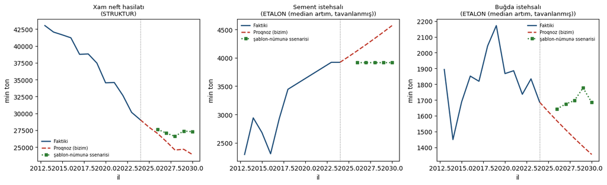

```python
import matplotlib.pyplot as plt

fig, axes = plt.subplots(1, 3, figsize=(13.5, 4.2))
demo_rows = [(35, "Xam neft hasilatı"), (130, "Sement istehsalı"), (7, "Buğda istehsalı")]

for ax, (row, title) in zip(axes, demo_rows):
    rec = next(r for r in results if r["row"] == row)
    Q = data_layer.vereq_actuals("2.4.1.4.", rec["name_az"], row=row)
    ax.plot(Q.index, Q.values, "-", color="#1f4e79", lw=1.8, label="Faktiki")
    fc = rec["level_path"]
    ax.plot([rec["last_year"]] + list(fc.index), [rec["last_val"]] + list(fc.values),
           "--", color="#c0392b", lw=1.8, label="Proqnoz (bizim)")
    if len(rec["ministry"]):
        ax.plot(rec["ministry"].index, rec["ministry"].values, ":", color="#2e7d32", lw=1.9,
               marker="s", ms=4, label="şablon-nümunə ssenarisi")
    ax.axvline(rec["last_year"], color="grey", ls=":", lw=1)
    ax.set_title(f"{title}\n({rec['method']})", fontsize=9.5)
    ax.set_xlabel("il"); ax.set_ylabel(rec["unit"])
    ax.legend(fontsize=7, frameon=False)

plt.tight_layout()
fig.savefig(os.path.join(config.FIG, "FR04_illustrative_products.png"), dpi=140)
plt.show()
```

**Nazirliklə müqayisə (aqreqat).** 178 məhsulun hamısı üçün ayrıca qrafik çəkmək əvəzinə, Nazirliyin öz Proqnoz sütunu mövcud olan məhsullar üzrə 2030-cu il üçün faiz fərqi bir cədvəldə ümumiləşdirilir.

```python
mb_rows = []
for rec in results:
    if len(rec["ministry"]) and 2030 in rec["ministry"].index:
        ours = rec["level_path"].loc[2030]
        mn = rec["ministry"].loc[2030]
        mb_rows.append(dict(series_id=rec["series_id"], name_az=rec["name_az"], driver=rec["driver"],
                            bizim_2030=ours, nazirlik_2030=mn,
                            ferq_pct=(ours / mn - 1) * 100 if mn != 0 else np.nan))
mb_df = pd.DataFrame(mb_rows).round({"bizim_2030": 1, "nazirlik_2030": 1, "ferq_pct": 1})
print(f"Nazirliyin 2030 Proqnoz dəyəri mövcud olan məhsul sayı: {len(mb_df)}")
print(f"Median fərq: {mb_df['ferq_pct'].median():.1f} %,  |fərq| median: {mb_df['ferq_pct'].abs().median():.1f} %")
mb_df.sort_values("ferq_pct", key=abs, ascending=False).head(15)
```

```
Nazirliyin 2030 Proqnoz dəyəri mövcud olan məhsul sayı: 129
Median fərq: 8.7 %,  |fərq| median: 26.5 %
```

|  | series_id | name_az | driver | bizim_2030 | nazirlik_2030 | ferq_pct |
| --- | --- | --- | --- | --- | --- | --- |
| 35 | v4_r060_mindkl | Şampan şərabı | g_cons_core | 95.9 | 2.8 | 3388.3 |
| 77 | v4_r111_minton | Xüsusi çəkisi 0,94-dən az olan xətti polietile... | g_inv_core | 240.2 | 92.0 | 161.1 |
| 75 | v4_r109_minton | Propen (propilen) | g_inv_core | 238.2 | 105.8 | 125.0 |
| 101 | v4_r142_ton | Tikişsiz boruların istehsalı üçün cins polad k... | g_inv_core | 0.0 | 5.0 | -100.0 |
| 79 | v4_r113_minton | Etilen | g_inv_core | 0.0 | 5.0 | -100.0 |
| 76 | v4_r110_minton | İzopropil spirti | g_inv_core | 0.0 | 5.0 | -100.0 |
| 30 | v4_r040_ton | Mis filizləri | nonoil_realg | 121.9 | 27094.2 | -99.5 |
| 56 | v4_r085_ton | Ayaqqabı üçün dəri | g_cons_core | 306.5 | 155.3 | 97.4 |
| 55 | v4_r084_minkvm | Laklı dəri və saxta laklı təbii dəri: metallaş... | g_cons_core | 423.8 | 214.7 | 97.4 |
| 43 | v4_r070_minton | Kardo və daraqla daranmış pambıq lifi | g_cons_core | 270.6 | 137.1 | 97.4 |
| 45 | v4_r072_minm2 | Düyünlərlə toxunan xalçalar | g_cons_core | 59.8 | 30.3 | 97.4 |
| 46 | v4_r074_mineded | Kişi və ya oğlanlar üçün trikotaj kostyum və k... | g_cons_core | 130.7 | 66.2 | 97.4 |
| 47 | v4_r075_mineded | Kişi və ya oğlanlar üçün kostyumlar | g_cons_core | 898.6 | 455.2 | 97.4 |
| 49 | v4_r077_mineded | İpəkdən və ipək tullantılarından hazırlanan şa... | g_cons_core | 115.3 | 58.4 | 97.4 |
| 52 | v4_r080_mineded | Kişi və ya oğlanlar üçün paltolar, gödəkçələr,... | g_cons_core | 351.0 | 177.8 | 97.4 |

**Aksizli mallar — xüsusi cədvəl.** Spesifikasiyanın mötərizəsi ("o cümlədən aksizli məhsullar") alkoqollu içkilər, tütün məmulatları, neft yanacaqları və avtomobilləri nəzərdə tutur (Azərbaycanın aksiz qanunvericiliyinin ümumi kateqoriyaları — bu, dəqiq hüquqi siyahı deyil, yaxınlaşmadır və Məhdudiyyətlər bölməsində qeyd olunur).

```python
EXCISE_SECTIONS = {"3.2.": "alkoqollu içkilər", "3.3.": "tütün məmulatları",
                  "3.10.": "neft yanacaqları", "3.20.": "avtomobillər"}

excise_rows = []
for rec in results:
    sec = p4.loc[p4["row"] == rec["row"], "section_no"].iloc[0]
    if sec in EXCISE_SECTIONS:
        excise_rows.append(dict(series_id=rec["series_id"], name_az=rec["name_az"],
                                kateqoriya=EXCISE_SECTIONS[sec], unit=rec["unit"],
                                method=rec["method"], v2025=rec["level_path"].loc[2025],
                                v2030=rec["level_path"].loc[2030]))
excise_df = pd.DataFrame(excise_rows).round({"v2025": 1, "v2030": 1})
print(f"Aksizli (yaxınlaşdırılmış) məhsul sayı: {len(excise_df)}")
excise_df.sort_values(["kateqoriya", "series_id"])
```

```
Aksizli (yaxınlaşdırılmış) məhsul sayı: 22
```

|  | series_id | name_az | kateqoriya | unit | method | v2025 | v2030 |
| --- | --- | --- | --- | --- | --- | --- | --- |
| 0 | v4_r060_mindkl | Şampan şərabı | alkoqollu içkilər | min dkl | ETALON (median artım, tavanlanmış) | 54.4 | 95.9 |
| 1 | v4_r061_mindkl | Tündlüyü 45.4% və daha az olan araq | alkoqollu içkilər | min dkl | ETALON (median artım, tavanlanmış) | 1567.5 | 1924.9 |
| 2 | v4_r062_mindkl | Üzüm şərabı və təzə üzümdən köpüklənən şərab | alkoqollu içkilər | min dkl | ETALON (median artım, tavanlanmış) | 895.8 | 841.7 |
| 3 | v4_r063_mindkl | Səməni pivəsi | alkoqollu içkilər | min dkl | ETALON (median artım, tavanlanmış) | 5458.1 | 6245.6 |
| 4 | v4_r064_mindkl | Viski, konyak | alkoqollu içkilər | min dkl | ETALON (median artım, tavanlanmış) | 849.6 | 1497.3 |
| 5 | v4_r065_mindkl | Alkoqolsuz içkilər | alkoqollu içkilər | min dkl | ETALON (median artım, tavanlanmış) | 55847.5 | 98422.3 |
| 19 | v4_r164_eded | Yük avtomobilləri | avtomobillər | ədəd | ETALON (median artım, tavanlanmış) | 27626.1 | 28506.5 |
| 20 | v4_r165_eded | Qoşqular və yarımqoşqular | avtomobillər | ədəd | SABİT (DATA-GAP, n<8) | 3.0 | 3.0 |
| 21 | v4_r166_eded | Minik avtomobilləri | avtomobillər | ədəd | ETALON (median artım, tavanlanmış) | 6801.2 | 11140.4 |
| 8 | v4_r097_minton | Neft məhsullarının istehsalı-cəmi | neft yanacaqları | min ton | ETALON (median artım, tavanlanmış) | 5269.1 | 4966.4 |
| 9 | v4_r098_minton | Avtobenzinlər | neft yanacaqları | min ton | ETALON (median artım, tavanlanmış) | 1259.8 | 1318.2 |
| 10 | v4_r099_minton | Hidrotəmizlənmiş benzin | neft yanacaqları | min ton | ETALON (median artım, tavanlanmış) | 176.8 | 119.3 |
| 11 | v4_r100_minton | Dizel yanacağı | neft yanacaqları | min ton | ETALON (median artım, tavanlanmış) | 2119.0 | 2436.9 |
| 12 | v4_r101_minton | Reaktiv mühərrik yanacağı | neft yanacaqları | min ton | ETALON (median artım, tavanlanmış) | 580.6 | 539.4 |
| 13 | v4_r102_minton | Soba mazutu | neft yanacaqları | min ton | STRUKTUR | 20.4 | 10.8 |
| 14 | v4_r103_minton | Neft koksu | neft yanacaqları | min ton | ETALON (median artım, tavanlanmış) | 164.7 | 96.4 |
| 15 | v4_r104_minton | Neft bitumu | neft yanacaqları | min ton | ETALON (median artım, tavanlanmış) | 251.7 | 194.5 |
| 16 | v4_r105_minton | Mühərrik yanacağı | neft yanacaqları | min ton | ETALON (median artım, tavanlanmış) | 0.0 | 0.0 |
| 17 | v4_r106_minton | Sürtkü yağları | neft yanacaqları | min ton | ETALON (median artım, tavanlanmış) | 10.7 | 5.7 |
| 18 | v4_r107_minton | Quru qaz | neft yanacaqları | min ton | ETALON (median artım, tavanlanmış) | 36.4 | 25.5 |
| 6 | v4_r067_ton | Sənayedə emal olunmuş tütün, tütün ekstraktlar... | tütün məmulatları | ton | ETALON (median artım, tavanlanmış) | 3681.8 | 3123.6 |
| 7 | v4_r068_mlneded | Tərkibində tütün və ya tütün qarışıqları və on... | tütün məmulatları | mln. ədəd | ETALON (median artım, tavanlanmış) | 17015.3 | 29986.8 |

## 8. Nəticələrin ixracı

Dörd çıxış ardıcıl yazılır: sıra lüğəti (`series_dictionary.csv`, 179 sətir — sətir 179 daxil, DATA-GAP qeydi ilə), proqnoz/faktiki sıralar (`forecast_long.csv`, natural həcm — səviyyə formasında, paketin öz presedentinə uyğun olaraq səviyyə sıraları bant daşımır, bax Məhdudiyyətlər), tənlik kataloqu (`equations_catalog.csv`, 157 cəhd edilmiş tənlik) və geriyə doğru sınaq nəticələri (artıq Bölmə 6-da yazılıb).

```python
# İngilis dilində adlar — statutar şablonun 179 sətrinin bir dəfəlik lüğəti
# (series_dictionary.csv-in 'name_en' sütunu üçün, notebook nəsri üçün deyil).
NAME_EN = {
    6: 'Cereals and pulses',
    7: 'of which, wheat',
    8: 'of which, rice (paddy)',
    9: 'Vegetables',
    10: 'Melons and gourds',
    11: 'Potatoes',
    12: 'Cotton',
    13: 'Tobacco (raw leaf)',
    14: 'Sugar beet',
    15: 'Sunflower (for seed)',
    16: 'Fruit and berries',
    17: 'Grapes',
    18: 'Tea leaf',
    20: 'Meat (live weight)',
    21: 'of which, beef',
    22: 'of which, mutton',
    23: 'of which, poultry meat',
    24: 'Eggs',
    25: 'Milk (raw weight)',
    26: 'Wool (raw weight)',
    27: 'Cocoons (raw weight)',
    28: 'Cattle (head)',
    29: 'Cows and buffalo (head)',
    30: 'Sheep and goats (head)',
    31: 'Pigs (head)',
    32: 'Poultry (head)',
    35: 'Crude oil extraction',
    36: 'Natural gas extraction',
    37: 'of which, marketed gas',
    39: 'Gold ores and concentrates',
    40: 'Copper ores',
    42: 'Gravel, crushed stone, pebbles and flint',
    43: 'Bentonite',
    44: 'Limestone and gypsum for construction',
    45: 'Construction sand',
    48: 'Beef (processed)',
    49: 'Poultry meat (processed)',
    50: 'Fruit and vegetable juices',
    51: 'Processed liquid milk',
    52: 'Refined sugar and granulated sugar',
    53: 'Butter',
    54: 'Cheese and curd',
    55: 'Vegetable oils',
    56: 'Flour',
    57: 'Bread and bakery products',
    58: 'Table salt',
    60: 'Sparkling wine (champagne)',
    61: 'Vodka, alcoholic strength <=45.4%',
    62: 'Grape wine and sparkling wine from fresh grapes',
    63: 'Barley beer',
    64: 'Whisky, brandy',
    65: 'Non-alcoholic beverages',
    67: 'Industrially processed tobacco, extracts and essences, homogenised/reconstituted tobacco n.e.c.',
    68: 'Cigars and cigarillos containing tobacco or tobacco substitutes',
    70: 'Carded or combed cotton fibre',
    71: 'Cotton yarn packaged for retail sale (excl. sewing thread)',
    72: 'Knotted carpets',
    74: 'Men\'s/boys\' knitted suits and ensembles',
    75: 'Men\'s/boys\' suits',
    76: 'Men\'s/boys\' underpants and briefs',
    77: 'Silk shawls, scarves, mufflers and veils',
    78: 'Tights, panty hose and stockings',
    79: 'Men\'s/boys\' industrial or occupational clothing (cotton/man-made fibres)',
    80: 'Men\'s/boys\' overcoats, car coats, capes and similar articles',
    81: 'Women\'s/girls\' dresses',
    82: 'Men\'s/boys\' shirts and undershirts',
    84: 'Patent leather and imitation patent/metallised leather',
    85: 'Leather for footwear',
    86: 'Men\'s leather outdoor footwear',
    88: 'Other wood-based parquet panels',
    89: 'Wooden door blocks (frames and leaves), door thresholds',
    91: 'Corrugated paper and paperboard',
    92: 'Paper handkerchiefs and tissues',
    94: 'Other printed matter (excl. simple printed materials)',
    95: 'Printing of books and children\'s picture/drawing books',
    97: 'Petroleum products, total',
    98: 'Motor gasoline',
    99: 'Hydrotreated naphtha/gasoline',
    100: 'Diesel fuel',
    101: 'Jet fuel',
    102: 'Fuel oil (mazut)',
    103: 'Petroleum coke',
    104: 'Petroleum bitumen',
    105: 'Motor fuel (mixed)',
    106: 'Lubricating oils',
    107: 'Dry gas',
    109: 'Propene (propylene)',
    110: 'Isopropyl alcohol',
    111: 'Linear polyethylene (density <0.94), primary forms',
    112: 'Other unsaturated acyclic hydrocarbons n.e.c.',
    113: 'Ethylene',
    114: 'Other polypropylene, primary forms',
    115: 'Aluminium sulphate or barium sulphate',
    116: 'Other paints and varnishes, water-based/dispersed',
    117: 'Methanol (methyl alcohol)',
    118: 'Urea',
    119: 'Aluminium sulphate or barium sulphate (duplicate name, distinct row)',
    121: 'Retail-packaged medicines containing other antibiotics',
    122: 'Other retail-packaged medicines, mixed or unmixed, n.e.c.',
    124: 'Rigid polyethylene pipes, tubes and hoses',
    125: 'Rigid polypropylene pipes, tubes and hoses',
    126: 'Other rigid polyethylene pipes, tubes and hoses n.e.c.',
    127: 'Plastic packaging containers',
    128: 'Plastic bottles and similar articles (capacity <=2 litres)',
    130: 'Cement',
    131: 'Prefabricated concrete structures for construction',
    132: 'Ready-mix concrete',
    133: 'Asphalt',
    134: 'Construction bricks',
    135: 'Paper-faced gypsum board and building board',
    136: 'Building plaster (gypsum)',
    137: 'Sheet glass',
    138: 'Ceramic tiles for floors, stoves and walls',
    139: 'Worked marble, travertine and alabaster',
    141: 'Non-alloy steel ingots/semis for seamless tube manufacture',
    142: 'Alloy steel ingots for seamless tube manufacture (excl. stainless)',
    143: 'Non-alloy steel bars, hot-rolled in coils',
    144: 'Aluminium foil',
    145: 'Primary (unwrought) aluminium',
    147: 'Prefabricated steel structures for construction',
    148: 'Other structures made of sheet material',
    149: 'Non-insulated multi-core steel wire, cables and ropes',
    151: 'Automatic regulating/control instruments and apparatus n.e.c.',
    153: 'Liquid dielectric transformers, power <=650 kVA',
    154: 'Liquid dielectric transformers, power >650 and <=10,000 kVA',
    155: 'Liquid dielectric transformers, power >10,000 kVA',
    156: 'Insulated electric wire/cable with connectors, voltage <=1000V',
    157: 'Household refrigerators',
    158: 'Boards, panels, consoles, cabinets for electric control/distribution',
    160: 'Parts of pumps for liquids and liquid elevators',
    161: 'Fire extinguishers',
    162: 'Tractors',
    164: 'Trucks (lorries)',
    165: 'Trailers and semi-trailers',
    166: 'Passenger cars',
    168: 'Railway and tramway track fixtures, fittings and equipment parts',
    169: 'Repair of railway locomotives, motor coaches and tramway rolling stock',
    170: 'Building and repair of ships and floating structures',
    172: 'Wooden office furniture',
    173: 'Wooden kitchen furniture',
    174: 'Wooden bedroom furniture',
    175: 'Upholstered seating, wooden frame',
    177: 'Repair of ships, boats and floating vessels (excl. pleasure/sport craft)',
    179: '[name lost to #REF! -- statutory template gives no product name for this row]',
    180: 'Jewellery and articles of precious metal',
    182: 'Conditional thermal electricity from thermal power plants',
    183: 'Gasworks gas (carbonisation, cracking, gasification or gas mixing)',
    184: 'Electricity from wind and solar power stations',
    186: 'Water sold to consumers',
    187: 'Natural water treatment and pipeline distribution services',
    190: 'Freight transported, transport sector total',
    191: 'Railway (freight, tons)',
    192: 'Road (freight, tons)',
    193: 'Sea (freight, tons)',
    194: 'Air (freight, tons)',
    195: 'Pipeline (freight, tons)',
    196: 'Oil pipeline (freight, tons)',
    197: 'of which, BTC pipeline (freight, tons)',
    198: 'Gas pipeline (freight, tons)',
    199: 'of which, SCP pipeline (freight, tons)',
    200: 'Freight turnover, transport sector total',
    201: 'Railway (freight turnover)',
    202: 'Road (freight turnover)',
    203: 'Sea (freight turnover)',
    204: 'Air (freight turnover)',
    205: 'Pipeline (freight turnover)',
    206: 'Oil pipeline (freight turnover)',
    207: 'of which, BTC pipeline (freight turnover)',
    208: 'Gas pipeline (freight turnover)',
    209: 'of which, SCP pipeline (freight turnover)',
    210: 'Passenger turnover, transport sector',
    211: 'Railway (passenger turnover)',
    212: 'Bus and taxi (passenger turnover)',
    213: 'Sea (passenger turnover)',
    214: 'Air (passenger turnover)',
    215: 'Metro (passenger turnover)',
    217: 'Mobile phone subscribers (numbers)',
    218: 'Fixed telephone sets',
    219: 'Fixed telephone sets per 100 inhabitants',
}
```

```python
_CON_BY_ROW = CON.set_index(CON["vereq_row"].astype(int))


def _dict_ref(row):
    """Statutar istinad mətni; dirçəldilən sətirlərdə DSK mənbəyi də açıq göstərilir."""
    if row == 179:
        return "8 vərəq, 2.4.1.4., sətir 179 — ad #REF!, məlumat mövcud deyil"
    if row in _CON_BY_ROW.index:
        _c = _CON_BY_ROW.loc[row]
        if row in REBASED:
            return (f"8 vərəq, 2.4.1.4., sətir {row} (2018+ #REF!) — sıra "
                    f"{_c['source_file'].split('/')[-1]} «{_c['source_label']}» üzərində "
                    f"{int(_c['year_first'])}–{int(_c['year_last'])} dövrü üçün dirçəldilib, "
                    f"{REBASE_ANCHOR}-ci ilin şablon səviyyəsinə bazalaşdırılıb")
        return (f"8 vərəq, 2.4.1.4., sətir {row} — 2018+ #REF!; DSK qarşılığı "
                f"({_c['source_label']}) ölçü vahidi/anlayış uyğunsuzluğuna görə "
                "istifadə edilmir (DATA-GAP)")
    return f"8 vərəq, 2.4.1.4., sətir {row}"


dict_rows = []
for _, r in p4.iterrows():
    row = int(r["row"])
    dict_rows.append(dict(
        series_code=r["series_id"], name_az=r["name_az"], name_en=NAME_EN[row],
        unit=r["unit"], fr="FR4",
        statutory_sheet_ref=_dict_ref(row),
    ))
dict_df = pd.DataFrame(dict_rows)
outputs.write_series_dictionary(dict_df)
print(f"series_dictionary.csv-ə yazıldı: {len(dict_df)} sətir (179 məhsulun hamısı, sətir 179 daxil)")
```

```
series_dictionary.csv-ə yazıldı: 179 sətir (179 məhsulun hamısı, sətir 179 daxil)
```

```python
fl_rows = []
for rec in results:
    sid = rec["series_id"]
    # dirçəldilən sətirlərdə faktiki sıra yenidən bazalaşdırılmış DSK sırasıdır (§2.1),
    # şablonun 2013-2017 fraqmenti deyil — səviyyə yolu da məhz ondan davam edir.
    Q = (REBASED[rec["row"]] if rec["row"] in REBASED
         else data_layer.vereq_actuals("2.4.1.4.", rec["name_az"], row=rec["row"]))
    for y, v in Q.items():
        fl_rows.append(dict(fr="FR4", series_code=sid, series_name_az=rec["name_az"], unit=rec["unit"],
                            year=int(y), kind="actual", source="ours", value=float(v),
                            lo80=np.nan, hi80=np.nan, lo50=np.nan, hi50=np.nan))
    for y in FY_EXT:
        fl_rows.append(dict(fr="FR4", series_code=sid, series_name_az=rec["name_az"], unit=rec["unit"],
                            year=int(y), kind="forecast", source="ours",
                            value=float(rec["level_path"].loc[y]),
                            lo80=np.nan, hi80=np.nan, lo50=np.nan, hi50=np.nan))
    for y, v in rec["ministry"].items():
        fl_rows.append(dict(fr="FR4", series_code=sid, series_name_az=rec["name_az"], unit=rec["unit"],
                            year=int(y), kind="forecast", source="template_sample", value=float(v),
                            lo80=np.nan, hi80=np.nan, lo50=np.nan, hi50=np.nan))

fl_df = pd.DataFrame(fl_rows)
assert not fl_df.duplicated(subset=["fr", "series_code", "year", "kind", "source"]).any(), (
    "forecast_long açar sütunlarında dublikat ola bilməz")
outputs.write_forecast_long(fl_df)
print(f"forecast_long.csv-ə yazıldı: {len(fl_df)} sətir "
      f"({fl_df['kind'].eq('actual').sum()} faktiki, "
      f"{((fl_df['kind']=='forecast')&(fl_df['source']=='ours')).sum()} bizim proqnoz, "
      f"{(fl_df['source']=='template_sample').sum()} şablon overlay)")
```

```
forecast_long.csv-ə yazıldı: 3984 sətir (2242 faktiki, 1068 bizim proqnoz, 674 şablon overlay)
```

```python
eq_rows = []
for rec in results:
    if rec["res"] is None:
        continue
    desc = (f"{rec['method']}: Δln(Q) sürücü kimi {rec['driver']} ilə qiymətləndirilir "
           f"({rec['driver_reason']}); GATE={'keçdi' if rec['gate_pass'] else 'keçmədi'}"
           + (", doğruluq həddinə görə geri çevrildi (|orta artım|>25%/il)"
              if rec.get("plausibility_override") else "")
           + (f", ETALON median artım (tavanlanmış) = {rec['med_pct_capped']:.2f} %/il istifadə olunur"
              if not rec["gate_pass"] else ""))
    eq_rows.append(rec["res"].catalog_row(
        eq_name=rec["series_id"], description=desc, lhs="Δln(Q)",
        series_code=rec["series_id"], fr="FR4", workbook="8 vərəq", sheet="2.4.1.4."))
eq_df = pd.DataFrame(eq_rows)
outputs.write_equations_catalog(eq_df)
print(f"equations_catalog.csv-ə yazıldı: {len(eq_df)} sətir "
      f"({eq_df['description'].str.contains('keçdi').sum()} GATE keçən, "
      f"{eq_df['description'].str.contains('keçmədi').sum()} ETALON-a keçən)")
```

```
equations_catalog.csv-ə yazıldı: 157 sətir (31 GATE keçən, 126 ETALON-a keçən)
```

**Eynilik və müstəqil yoxlama.** Səviyyə yolunun mürəkkəbləşdirilməsi (compounding) düzgünlüyü, tavanlanmış artımın faktiki ixrac olunan yolla üst-üstə düşməsi və gələcəyə baxışın olmaması müstəqil yoxlanılır.

```python
v = validate.Verifier("FR4 — Natural göstəricilər")

# 1. Kompozit ID unikallığı (struktur mühafizə)
v.ok("series_id kompozit identifikatoru unikaldır", p4["series_id"].is_unique)

# 2. Tavanlanmış ETALON artımının ixrac olunan səviyyə yolunda İSTİFADƏ OLUNDUĞU (uyğunluq yoxlanışı)
_etalon_check = next(r for r in results if r["method"].startswith("ETALON"))
# 2024→2025 bir pillə mürəkkəbləşmə — hər addımda EYNİ tavanlanmış templə
v.close("ETALON nümunəsi: ixrac olunan səviyyə addımı = tavanlanmış artım",
       (_etalon_check["level_path"].loc[2025] / _etalon_check["last_val"]) - 1,
       _etalon_check["med_pct_capped"] / 100.0, tol=1e-9)

# 3. Gələcəyə baxış yoxdur — BİR nümunə deyil, qiymətləndirilən BÜTÜN tənliklər.
#    Əvvəllər yalnız birinci STRUKTUR sətri yoxlanılırdı (157 tənlikdən biri).
_all_fit = [r for r in results if r["res"] is not None]
_worst = max(int(r["res"].sample[1]) for r in _all_fit)
v.ok(f"gələcəyə baxış yoxdur: qiymətləndirilən {len(_all_fit)} tənliyin HAMISI",
     _worst <= LA, f"ən gec nümunə sonu {_worst} (hədd {LA})")
# şablonun hesabat pəncərəsi 2024-də bitir, ona görə tənliklərin nümunəsi də orada bitməlidir
_tmpl_end = max(int(r["res"].sample[1]) for r in _all_fit if not r.get("revived"))
v.ok("şablon əsaslı tənliklərin nümunəsi hesabat pəncərəsində (≤2024) bitir",
     _tmpl_end <= 2024, f"ən gec nümunə sonu {_tmpl_end}")

# 4. Sətir 179 heç bir çıxış cədvəlində YOXDUR (istisna həqiqətən tətbiq olunub)
v.ok("sətir 179 forecast_long-da yoxdur",
    not fl_df["series_code"].eq("v4_r179_minmanat").any())
v.ok("sətir 179 series_dictionary-də DATA-GAP qeydi ilə VAR",
    dict_df.loc[dict_df["series_code"] == "v4_r179_minmanat", "statutory_sheet_ref"]
    .str.contains("#REF!").all())

# 5. cap-hit hesabatının doğruluğu: bütün cap_hit=True sətirlərdə |capped-raw|>0
_cap_check = summ.loc[summ["cap_hit"] == True]
v.ok("bütün 'cap_hit' bayraqlı sətirlərdə tavanlanmış dəyər xam dəyərdən fərqlənir",
    bool((_cap_check["med_pct_capped"] - _cap_check["med_pct_raw"]).abs().gt(1e-9).all()))

# 6. DİRÇƏLİŞ: yenidən bazalaşdırma lövbəri hər dirçəldilən sətirdə DƏQİQ bağlanır
for _row, _s in REBASED.items():
    _lab = p4_by_row.loc[_row, "name_az"]
    v.close(f"sətir {_row} — {REBASE_ANCHOR} lövbəri şablonun öz dəyərinə bərabərdir",
            float(_s.loc[REBASE_ANCHOR]),
            float(data_layer.vereq_actuals("2.4.1.4.", _lab, row=_row).loc[REBASE_ANCHOR]),
            tol=1e-9)
v.ok("dirçəldilən sətirlərin heç biri artıq SABİT üsulunda deyil",
     not any(r["method"].startswith("SABİT") for r in results if r.get("revived")))
v.ok("nisbəti sabit olmayan sətir (50) dirçəldilməyib və SABİT qalır",
     50 not in REBASED and
     next(r["method"] for r in results if r["row"] == 50).startswith("SABİT"))

v.assert_all()
```

```
==============================================================
  YOXLAMA: FR4 — Natural göstəricilər
==============================================================
  [PASS] series_id kompozit identifikatoru unikaldır
  [PASS] ETALON nümunəsi: ixrac olunan səviyyə addımı = tavanlanmış artım
         maksimal fərq 0.000e+00 ≤ 1.0e-09
  [PASS] gələcəyə baxış yoxdur: qiymətləndirilən 157 tənliyin HAMISI
         ən gec nümunə sonu 2024 (hədd 2025)
  [PASS] şablon əsaslı tənliklərin nümunəsi hesabat pəncərəsində (≤2024) bitir
         ən gec nümunə sonu 2024
  [PASS] sətir 179 forecast_long-da yoxdur
  [PASS] sətir 179 series_dictionary-də DATA-GAP qeydi ilə VAR
  [PASS] bütün 'cap_hit' bayraqlı sətirlərdə tavanlanmış dəyər xam dəyərdən fərqlənir
  [PASS] sətir 48 — 2017 lövbəri şablonun öz dəyərinə bərabərdir
         maksimal fərq 0.000e+00 ≤ 1.0e-09
  [PASS] sətir 49 — 2017 lövbəri şablonun öz dəyərinə bərabərdir
         maksimal fərq 0.000e+00 ≤ 1.0e-09
  [PASS] sətir 51 — 2017 lövbəri şablonun öz dəyərinə bərabərdir
         maksimal fərq 0.000e+00 ≤ 1.0e-09
  [PASS] sətir 52 — 2017 lövbəri şablonun öz dəyərinə bərabərdir
         maksimal fərq 0.000e+00 ≤ 1.0e-09
  [PASS] sətir 53 — 2017 lövbəri şablonun öz dəyərinə bərabərdir
         maksimal fərq 0.000e+00 ≤ 1.0e-09
  [PASS] sətir 54 — 2017 lövbəri şablonun öz dəyərinə bərabərdir
         maksimal fərq 0.000e+00 ≤ 1.0e-09
  [PASS] sətir 55 — 2017 lövbəri şablonun öz dəyərinə bərabərdir
         maksimal fərq 0.000e+00 ≤ 1.0e-09
  [PASS] sətir 56 — 2017 lövbəri şablonun öz dəyərinə bərabərdir
         maksimal fərq 0.000e+00 ≤ 1.0e-09
  [PASS] sətir 57 — 2017 lövbəri şablonun öz dəyərinə bərabərdir
         maksimal fərq 0.000e+00 ≤ 1.0e-09
  [PASS] sətir 58 — 2017 lövbəri şablonun öz dəyərinə bərabərdir
         maksimal fərq 0.000e+00 ≤ 1.0e-09
  [PASS] dirçəldilən sətirlərin heç biri artıq SABİT üsulunda deyil
  [PASS] nisbəti sabit olmayan sətir (50) dirçəldilməyib və SABİT qalır
--------------------------------------------------------------
  19/19 yoxlama uğurlu
```

```python
fl_disk = pd.read_csv(os.path.join(config.OUT, "forecast_long.csv"))
eq_disk = pd.read_csv(os.path.join(config.OUT, "equations_catalog.csv"))
dict_disk = pd.read_csv(config.O_SERIES_DICT)
bt_disk = pd.read_csv(os.path.join(config.OUT, "validation_backtest.csv"))

print("forecast_long.csv, FR4 sətirləri:        ", int((fl_disk["fr"] == "FR4").sum()))
print("equations_catalog.csv, FR4 sətirləri:     ", int((eq_disk["fr"] == "FR4").sum()))
print("series_dictionary.csv, FR4 sətirləri:     ", int((dict_disk["fr"] == "FR4").sum()))
print("validation_backtest.csv, panel sətirləri: ",
     int(bt_disk["series_code"].isin(summ["series_id"]).sum()))
```

```
forecast_long.csv, FR4 sətirləri:         3984
equations_catalog.csv, FR4 sətirləri:      157
series_dictionary.csv, FR4 sətirləri:      179
validation_backtest.csv, panel sətirləri:  600
```

## 9. Məhdudiyyətlər

**DATA-GAP (sətir 179):** statutar şablonun 2.4.1.4. vərəqində 179-cu sətrin ADI özü `#REF!` xətasıdır və bu sətir üçün nə hesabat, nə proqnoz dəyəri mövcuddur (14/14 xana `#REF!`). Bu məhsul heç bir üsulla proqnozlaşdırıla bilmir və heç bir yerdə sıfır və ya təxmini dəyərlə əvəzlənməyib — `forecast_long.csv`-də YOXDUR, `series_dictionary.csv`-də isə açıq DATA-GAP qeydi ilə qeydə alınıb.

**11 qida məhsulu (48–58-ci sətirlər) — DATA-GAP BAĞLANDI, bir istisna ilə.** Şablonun bu sətirləri 2018-dən sonra `#REF!`-dir; onlardan **onu** DSK-nın 18-ci sənaye cədvəli və 1.46/1.47 kənd təsərrüfatı cədvəlləri üzərində, 2017-ci ilin şablon səviyyəsinə yenidən bazalaşdırılmaqla dirçəldilib (§2.1) və artıq şablonun 12 illik pəncərəsindən **iki-üç dəfə uzun** nümunə ilə, tam GATE qaydası və ayrıca geriyə doğru sınaqla (§6.1) proqnozlaşdırılır. **Bir sətir — 50, meyvə və tərəvəz şirələri — dirçəldilmir**: şablon min dkl, DSK isə min ton ölçür və DSK sətri konservləri şirələrlə birlikdə sayır; ortaq beş ildə nisbət 2,41-dən 24,57-yə qədər dəyişir (CV 56 %), yəni sabit çevirmə əmsalı yoxdur. Bu sətir SABİT (2017 səviyyəsi) qalır və Nazirliyə göndəriləcək sorğuda **ölçü vahidi uzlaşdırılması** kimi saxlanılır.

**Proqnoz üfüqünün uzadılması (2025 daxil).** Statutar şablonun hesabat hissəsi 2024-də bitdiyi üçün FR4-ün proqnoz üfüqü digər FR-lərdən fərqli olaraq 2025–2030-u əhatə edir; 2025 "faktiki" DEYİL, sürücülərin bilinən 2025 dəyərləri ilə qurulmuş nowcast-dır. Bu, digər FR-lərin 2025 faktiki dəyərlərinə malik olması ilə uyğunsuzluq yaradır və dashboard istifadəçisi bunu nəzərə almalıdır.

**DEVIASİYA (sürücü təyinatı):** brifin nəzərdə tutduğu "uyğunsuz məhsullar üçün SEKTORUN FR2 artımı sürücü kimi" qaydası hərfi tətbiq oluna bilmədi, çünki FR2 (istehsal strukturu) bu tikinti dalğasında (Wave D, paralel qrup) FR4 ilə eyni vaxtda qurulur və D2 DAG-ına görə FR4 ondan asılı DEYİL. Bunun əvəzinə hər bölmə kodu FR1 nüvəsinin dörd mövcud yolundan (neft, qeyri-neft, investisiya, istehlak) birinə birbaşa təyin edilib — kənd təsərrüfatı, mədənçıxarmanın digər sahələri, kommunal, nəqliyyat və rabitə sahələri üçün bu, `nonoil_realg` aqreqat yolu ilə **vəkalətçi (proksi)** əlaqədir, sahə-səviyyəli dəqiq deyil. FR2 gələcəkdə əlavə olunarsa, bu **62** məhsulun (`nonoil_realg` sürücülü) təyinatı sahə-səviyyəli artıma yüksəldilə bilər.

**`nonoil_realg` sürücüsünün tarixi və proqnozu eyni tərif üzərində deyil.** Sürücünün faktiki hissəsi statutar sıradır (bazar qiymətləri; bütün mədənçıxarma neft blokunda), proqnoz hissəsi isə `assumptions.csv`-in `nonoil_realg` açarıdır və istehsal metoduna keçiddən sonra o, FR02-nin aşağıdan-yuxarı ƏLAVƏ DƏYƏR aqreqatıdır (qeyri-neft mədənçıxarma qeyri-neft blokunda). İki bazanın fərqi FR02, Bölmə 7.4-də sətir-sətir ölçülür (2017–2025 üzrə orta mütləq fərq ~0,5 f.b.). Bu sürücü ilə qiymətləndirilən tənliklərin əmsalı statutar baza üzərində, proqnoz yolu isə istehsal hesabı bazası üzərində olduğu üçün 62 məhsulun yolunda kiçik, lakin sistematik bir uyğunsuzluq qalır; ölçüsü məhsul səviyyəsindəki qeyri-müəyyənlikdən xeyli kiçikdir.

**Panel sınağının şərtiliyi.** Bölmə 6-nın STRUKTUR modeli proqnoz anında sürücünün həmin ilki faktiki dəyərini bilir, RW etalonu isə bilmir. Bu, proqnozdakı istifadə rejimi ilə eynidir (sürücü fərziyyə yolu ilə verilir), lakin bacarıq rəqəmini STRUKTUR-un xeyrinə çevirir. Paketin FR01 dəftəri eyni vəziyyəti şərti/şərtsiz ayrımı ilə nəşr edir; FR4-də panel kiçik olduğu üçün ayrıca ex-ante variant hesablanmır, şərtilik isə açıq qeyd olunur.

**Bant (yelpik zolağı) qərarı.** Paketin özünün presedentinə uyğun olaraq (FR1-in `gdp_nom`, `oil_nom` və s. səviyyə sıraları da bant daşımır, yalnız artım tempi sıraları daşıyır), FR4-ün 178 natural göstərici SƏVİYYƏSİ `forecast_long.csv`-də bant DAŞIMIR — çünki hər məhsul üçün ayrıca artım-tempi `series_code` yaratmaq (356 sıra) miqyas baxımından qeyri-mütənasib olardı. Parametr və qalıq qeyri-müəyyənliyi STRUKTUR tənliklərinin HAC standart xətası (`equations_catalog.csv`) və təmsilçi panelin geriyə doğru sınaq RMSE-si (`validation_backtest.csv`) vasitəsilə hesabat edilir, lakin hər məhsulun səviyyə yolu üçün ayrıca lo80/hi80 YOXDUR.

**Aksizli mallar təsnifatı yaxınlaşmadır.** Bölmə 7-dəki aksiz cədvəli Azərbaycanın aksiz qanunvericiliyinin ümumi kateqoriyalarına (alkoqol, tütün, neft yanacaqları, avtomobillər) əsaslanır, dəqiq hüquqi maddə-maddə siyahı deyil.